# TP 1: Regresión lineal

F. Ayelén Opazo

30 de octubre de 2021

**Enfoque Estadístico del Aprendizaje**

## Planteo del Problema

El objetivo general del trabajo es poder crear una serie de modelos lineales para explicar y predecir el peso de los estudiantes según la información que proporciona la 3° Encuesta Mundial de Salud Escolar (EMSE), provistos por el Ministerio de Salud de la República Argentina. Esta encuesta trata sobre temas de salud y hábitos de las personas en la escuela secundaria que pueden impactar en su salud. Los datasets utilizados para el desarrollo de este trabajo corresponden a un recorte (muestra) del dataset original provisto por la cátedra, luego del tratamiento de valores atípicos e ingeniería de atributos. * El trabajo fue realizado de manera individual y en ocasiones se utilizó código visto en las clases.

```r
message = FALSE
```

```r
# Cargamos librerías

library("tidyverse")
library("dplyr")
library("knitr")
library("GGally")
library("ggplot2")
library("corrr")
library("psych")
library("corrplot")
library("gridExtra")
library("tidymodels")
library("kableExtra")
library("Metrics")
```

## Exploración de los datos

**Levantamos el dataset de entrenamiento y observamos su estructura y tipo de variables**

```r
ds_train<- read.csv("encuesta_salud_train.csv")

glimpse(ds_train)
```

```
Rows: 7,024
Columns: 16
$ record                        <int> 502, 26488, 31473, 14154, 36578, 53730, 11892, 35549, 14928, ~
$ edad                          <int> 17, 15, 15, 16, 17, 15, 13, 17, 17, 16, 16, 14, 15, 17, 15, 1~
$ genero                        <chr> "Femenino", "Masculino", "Masculino", "Masculino", "Masculino~
$ nivel_educativo               <chr> "2do aÃ±o/11vo grado nivel Polimodal o 4to aÃ±o nivel Secunda~
$ altura                        <int> 165, 178, 172, 170, 170, 178, 156, 163, 164, 167, 185, 146, 1~
$ peso                          <int> 62, 62, 62, 65, 75, 88, 46, 60, 57, 51, 100, 33, 62, 70, 80, ~
$ frecuencia_hambre_mensual     <chr> "Rara vez", "Rara vez", "Nunca", "Nunca", "Rara vez", "Nunca"~
$ dias_consumo_comida_rapida    <int> 0, 0, 3, 1, 1, 2, 0, 0, 0, 3, 4, 2, 1, 1, 3, 0, 0, 0, 0, 1, 0~
$ edad_consumo_alcohol          <chr> "14 o 15 aÃ±os", "7 aÃ±os o menos", "Nunca tomÃ© alcohol mÃ¡s~
$ consumo_diario_alcohol        <dbl> 5.0, 4.0, 0.0, 0.0, 0.0, 5.0, 1.0, 0.5, 5.0, 0.0, 5.0, 0.0, 0~
$ dias_actividad_fisica_semanal <int> 7, 7, 7, 7, 0, 7, 0, 2, 7, 3, 2, 2, 7, 1, 4, 0, 1, 6, 5, 7, 3~
$ consumo_semanal_frutas        <chr> "No comÃ frutas durante los Ãºltimos 7 dÃas", "No comÃ fru~
$ consumo_semanal_verdura       <chr> "4 a 6 veces durante los Ãºltimos 7 dÃas", "4 a 6 veces dura~
$ consumo_semanal_gaseosas      <chr> "1 a 3 veces durante los Ãºltimos 7 dÃas", "1 a 3 veces dura~
$ consumo_semanal_snacks        <chr> "1 a 3 veces durante los Ãºltimos 7 dÃas", "No comÃ comida ~
$ consumo_semanal_comida_grasa  <chr> "No comÃ comida alta en grasa en los Ãºltimos 7 dÃas", "4 a~
```

**Limpieza de los datos**

```r
# Limpiamos un poco las variables string
string_cleaning <- function(x){
  x <- gsub("aÃ±o", "año", x)
  x <- gsub("tomÃ©", "tome", x)
  x <- gsub("mÃ¡s", "mas", x)
  x <- gsub("comÃ", "comi", x)
  x <- gsub("Ãºltimo", "ultimo", x)
  x <-gsub("dÃa", "dia", x)
  return(x)
}

#aplicamos función a 'ds_train$nivel_educativo'
ds_train$nivel_educativo <- sapply(ds_train[,'nivel_educativo'],FUN = string_cleaning)

#aplicamos función a 'ds_train$edad_consumo_alcohol'
ds_train$edad_consumo_alcohol <- sapply(ds_train[,'edad_consumo_alcohol'],FUN = string_cleaning)

#aplicamos función a 'ds_train$consumo_semanal_frutas'
ds_train$consumo_semanal_frutas <- sapply(ds_train[,'consumo_semanal_frutas'],FUN = string_cleaning)

#aplicamos función a 'ds_train$consumo_semanal_verdura'
ds_train$consumo_semanal_verdura <- sapply(ds_train[,'consumo_semanal_verdura'],FUN = string_cleaning)

#aplicamos función a 'ds_train$consumo_semanal_gaseosas'
ds_train$consumo_semanal_gaseosas <- sapply(ds_train[,'consumo_semanal_gaseosas'],FUN = string_cleaning)

#aplicamos función a 'ds_train$consumo_semanal_snacks'
ds_train$consumo_semanal_snacks <- sapply(ds_train[,'consumo_semanal_snacks'],FUN = string_cleaning)

#aplicamos función a 'ds_train$consumo_semanal_comida_grasa'
ds_train$consumo_semanal_comida_grasa <- sapply(ds_train[,'consumo_semanal_comida_grasa'],FUN = string_cleaning)


# Acortamos los nombres de las variables de consumo semanal

names(ds_train)[names(ds_train) == 'consumo_semanal_frutas'] <- 'frutas'
names(ds_train)[names(ds_train) == 'consumo_semanal_verdura'] <- 'verdura'
names(ds_train)[names(ds_train) == 'consumo_semanal_gaseosas'] <- 'gaseosas'
names(ds_train)[names(ds_train) == 'consumo_semanal_snacks'] <- 'snacks'
names(ds_train)[names(ds_train) == 'consumo_semanal_comida_grasa'] <- 'grasas'
```

Se trata de un dataset de 7024 (respuestas de los estudiantes a la encuesta) con 16 variables (o preguntas de la encuesta) que lo componen.

```r
dim(ds_train)
```

```
[1] 7024   16
```

**Vemos cómo quedó el head de nuestro dataset**

```r
head(ds_train)
```

|  | record | edad | genero | nivel_educativo | altura | peso | frecuencia_hambre_mensual | dias_consumo_comida_rapida | edad_consumo_alcohol | consumo_diario_alcohol | dias_actividad_fisica_semanal | frutas | verdura | gaseosas | snacks | grasas |
| --- | --- | --- | --- | --- | --- | --- | --- | --- | --- | --- | --- | --- | --- | --- | --- | --- |
| 1 | 502 | 17 | Femenino | 2do año/11vo grado nivel Polimodal o 4to año nivel Secundario | 165 | 62 | Rara vez | 0 | 14 o 15 años | 5 | 7 | No comi frutas durante los ultimos 7 dias | 4 a 6 veces durante los ultimos 7 dias | 1 a 3 veces durante los ultimos 7 dias | 1 a 3 veces durante los ultimos 7 dias | No comi comida alta en grasa en los ultimos 7 dias |
| 2 | 26488 | 15 | Masculino | 1er año/10mo grado nivel Polimodal o 3er año nivel Secundario | 178 | 62 | Rara vez | 0 | 7 años o menos | 4 | 7 | No comi frutas durante los ultimos 7 dias | 4 a 6 veces durante los ultimos 7 dias | 1 a 3 veces durante los ultimos 7 dias | No comi comida salada o snacks en los ultimos 7 dias | 4 a 6 veces durante los ultimos 7 dias |
| 3 | 31473 | 15 | Masculino | 2do año/11vo grado nivel Polimodal o 4to año nivel Secundario | 172 | 62 | Nunca | 3 | Nunca tome alcohol mas que unos pocos sorbos | 0 | 7 | No comi frutas durante los ultimos 7 dias | 1 vez al dia | 4 a 6 veces durante los ultimos 7 dias | 4 a 6 veces durante los ultimos 7 dias | No comi comida alta en grasa en los ultimos 7 dias |
| 4 | 14154 | 16 | Masculino | 1er año/10mo grado nivel Polimodal o 3er año nivel Secundario | 170 | 65 | Nunca | 1 | 14 o 15 años | 0 | 7 | 4 a 6 veces durante los ultimos 7 dias | 4 o mas veces al dia | 1 a 3 veces durante los ultimos 7 dias | 1 a 3 veces durante los ultimos 7 dias | No comi comida alta en grasa en los ultimos 7 dias |
| 5 | 36578 | 17 | Masculino | 2do año/11vo grado nivel Polimodal o 4to año nivel Secundario | 170 | 75 | Rara vez | 1 | 16 o 17 años | 0 | 0 | 2 veces al dia | 1 a 3 veces durante los ultimos 7 dias | 1 vez al dia | No comi comida salada o snacks en los ultimos 7 dias | 1 a 3 veces durante los ultimos 7 dias |
| 6 | 53730 | 15 | Masculino | 1er año/10mo grado nivel Polimodal o 3er año nivel Secundario | 178 | 88 | Nunca | 2 | 8 o 9 años | 5 | 7 | 1 vez al dia | 2 veces al dia | 4 a 6 veces durante los ultimos 7 dias | 4 a 6 veces durante los ultimos 7 dias | 4 a 6 veces durante los ultimos 7 dias |

**Obtenemos un resumen de los datos**

```r
summary(ds_train)
```

```
     record           edad          genero          nivel_educativo        altura
 Min.   :   49   Min.   :12.00   Length:7024        Length:7024        Min.   :125.0
 1st Qu.:15076   1st Qu.:14.00   Class :character   Class :character   1st Qu.:157.0
 Median :28324   Median :15.00   Mode  :character   Mode  :character   Median :164.0
 Mean   :28605   Mean   :15.02                                         Mean   :164.3
 3rd Qu.:42310   3rd Qu.:16.00                                         3rd Qu.:170.0
 Max.   :57091   Max.   :18.00                                         Max.   :200.0
      peso        frecuencia_hambre_mensual dias_consumo_comida_rapida edad_consumo_alcohol
 Min.   : 27.00   Length:7024               Min.   :0.0000             Length:7024
 1st Qu.: 50.00   Class :character          1st Qu.:0.0000             Class :character
 Median : 58.00   Mode  :character          Median :0.0000             Mode  :character
 Mean   : 59.41                             Mean   :0.7615
 3rd Qu.: 66.00                             3rd Qu.:1.0000
 Max.   :144.00                             Max.   :7.0000
 consumo_diario_alcohol dias_actividad_fisica_semanal    frutas            verdura
 Min.   :0.000          Min.   :0.00                  Length:7024        Length:7024
 1st Qu.:0.000          1st Qu.:1.00                  Class :character   Class :character
 Median :1.000          Median :3.00                  Mode  :character   Mode  :character
 Mean   :1.794          Mean   :3.25
 3rd Qu.:4.000          3rd Qu.:5.00
 Max.   :5.000          Max.   :7.00
   gaseosas            snacks             grasas
 Length:7024        Length:7024        Length:7024
 Class :character   Class :character   Class :character
 Mode  :character   Mode  :character   Mode  :character
```

```r
# Notamos que la variable "edad_consumo_alcohol" es tipo character y no numérica porque contiene valores de respuesta discretas, en escala ordinal

unique(ds_train$edad_consumo_alcohol)
```

```
[1] "14 o 15 años"                                 "7 años o menos"
[3] "Nunca tome alcohol mas que unos pocos sorbos" "16 o 17 años"
[5] "8 o 9 años"                                   "10 o 11 años"
[7] "12 o 13 años"                                 "18 años o mas"
```

**No se encuentran a priori valores NA**

```r
sum(is.na(ds_train))
```

```
[1] 0
```

**Tampoco se encuentran filas duplicadas**

```r
sum(duplicated(ds_train))
```

```
[1] 0
```

**Vemos las distibuciones de las variables numéricas**

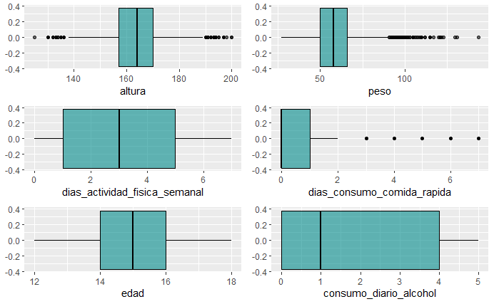

```r
n1 <- ggplot(data = ds_train, aes(x = altura)) +
  geom_boxplot(position = "identity", alpha = 0.6,  col='black', fill='darkcyan')
n2 <- ggplot(data = ds_train, aes(x = peso)) +
  geom_boxplot(position = "identity", alpha = 0.6,  col='black', fill='darkcyan')
n3<- ggplot(data = ds_train, aes(x = dias_actividad_fisica_semanal)) +
  geom_boxplot(position = "identity", alpha = 0.6, col='black', fill='darkcyan')
n4 <- ggplot(data = ds_train, aes(x = dias_consumo_comida_rapida)) +
  geom_boxplot(position = "identity", alpha = 0.6, col='black', fill='darkcyan')
n5 <- ggplot(data = ds_train, aes(x = edad)) +
  geom_boxplot(position = "identity", alpha = 0.6,  col='black', fill='darkcyan')
n6 <- ggplot(data = ds_train, aes(x = consumo_diario_alcohol)) +
  geom_boxplot(position = "identity", alpha = 0.6,  col='black', fill='darkcyan')

grid.arrange(n1, n2, n3, n4, n5, n6)
```

**Y las distribuciones de las variables categóricas**

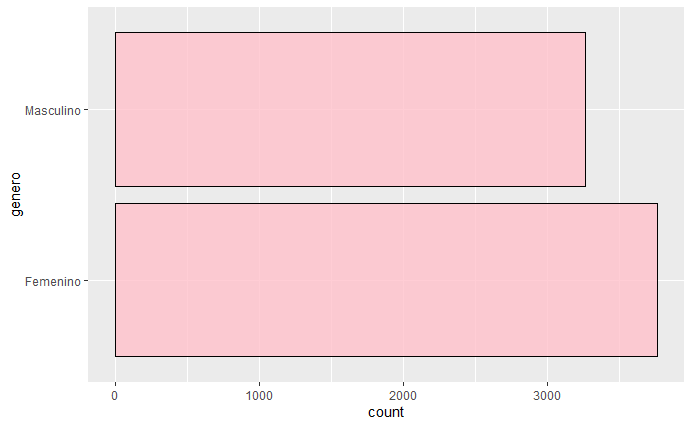

```r
c1<- ggplot(data = ds_train, aes(x = genero)) +
  geom_bar(position = "identity", alpha = 0.8, col='black', fill='pink')+ coord_flip()
c2 <- ggplot(data = ds_train, aes(x = nivel_educativo)) +
  geom_bar(position = "identity", alpha = 0.8, col='black', fill='pink')+ coord_flip()
c3 <- ggplot(data = ds_train, aes(x = frecuencia_hambre_mensual)) +
  geom_bar(position = "identity", alpha = 0.8,  col='black', fill='pink')+ coord_flip()
c4 <- ggplot(data = ds_train, aes(x = edad_consumo_alcohol)) +
  geom_bar(position = "identity", alpha = 0.8,  col='black', fill='pink')+ coord_flip()
c5 <- ggplot(data = ds_train, aes(x = frutas)) +
  geom_bar(position = "identity", alpha = 0.8,  col='black', fill='pink')+ coord_flip()
c6 <- ggplot(data = ds_train, aes(x = verdura)) +
  geom_bar(position = "identity", alpha = 0.8,  col='black', fill='pink')+ coord_flip()
c7 <- ggplot(data = ds_train, aes(x = gaseosas)) +
  geom_bar(position = "identity", alpha = 0.8,  col='black', fill='pink')+ coord_flip()
c8 <- ggplot(data = ds_train, aes(x = snacks)) +
  geom_bar(position = "identity", alpha = 0.8,  col='black', fill='pink')+ coord_flip()
c9 <- ggplot(data = ds_train, aes(x = grasas)) +
  geom_bar(position = "identity", alpha = 0.8,  col='black', fill='pink')+ coord_flip()

c1
```

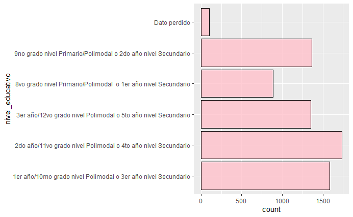

```r
c2
```

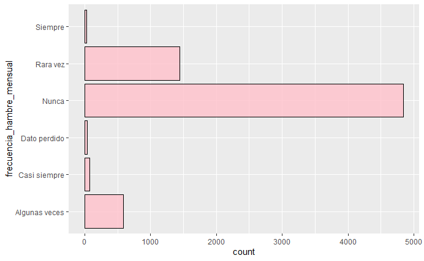

```r
c3
```

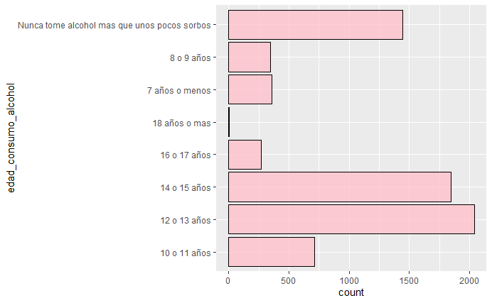

```r
c4
```

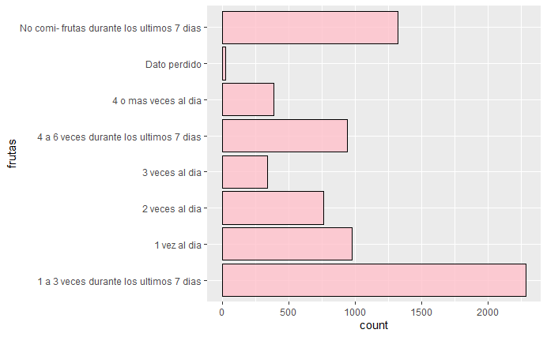

```r
c5
```

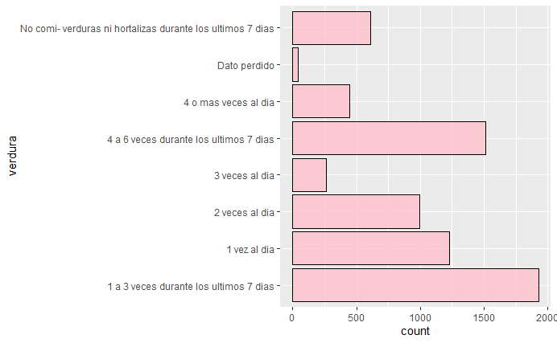

```r
c6
```

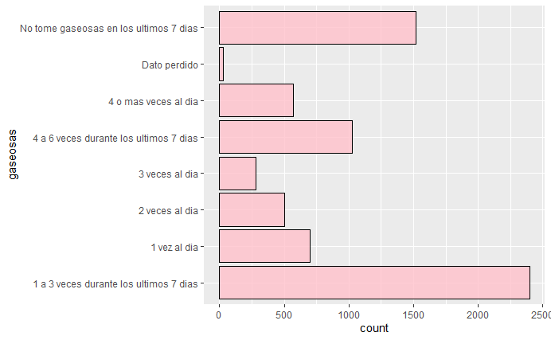

```r
c7
```

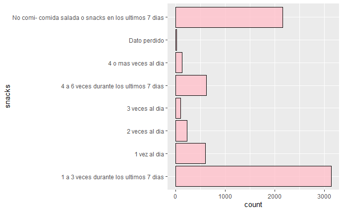

```r
c8
```

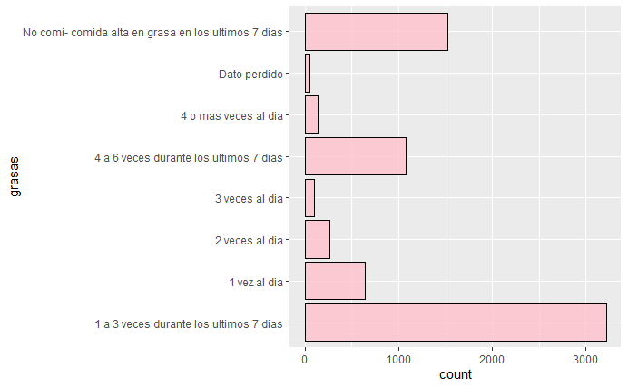

```r
c9
```

Como primera observación general podemos decir que la muestra se trata de 7024 estudiantes con edades entre 12 y 18 años (una media de 15 años), varones y mujeres (apenas un poco más de mujeres que de varones), con una media de altura de 164.3 y un peso medio de 59.41kg. La mayoría son estudiantes de 4to año de secundaria y la minoría es de 1er año de secundaria. En cuanto a hábitos alimenticios, el consumo de comida rápida es de una media menor a un día, el de alcohol de casi 2 día en promedio (podríamos pensar en días de fin de semana) y actividad física semanal de 3 días en promedio. En esta muestra la gran mayoría de los estudiantes nunca han sentido que pasaron hambre, dicen que consumen frutas, verduras, grasas, gaseosas y snacks entre 1 y 3 veces a la semana (siendo esta opción en cada caso la más frecuente en la encuesta) y comenzaron a tomar alcohol entre los 12 y los 15 años (existiendo una proporción amplia también que nunca probó).

### Detección de valores faltantes

Vemos que pese a no encontrar valores NA, en algunas variables se presenta el valor “Dato perdido”, con lo cual lo consideramos como faltante. A continuación vemos en profundidad en qué variables se encuentran estos datos perdidos y en qué proporción.

```r
# Armo una tabla por variable que indique cantidad de faltantes y valores unicos que existe en el dataset
tabla <- ds_train %>% gather(.,
                                 key   = Variables,
                                 value = Valores) %>%
  group_by(Variables) %>%
  summarise(valores_unicos = n_distinct(Valores),
            valores_faltantes = sum(Valores=="Dato perdido"),
            porcentaje_faltantes = round(sum(Valores=="Dato perdido")/nrow(ds_train)*100,2)) %>%
  arrange(desc(porcentaje_faltantes), valores_unicos) # ordenamos por porcentaje de faltantes y valores unicos

tabla
```

| Variables | valores_unicos | valores_faltantes | porcentaje_faltantes |
| --- | --- | --- | --- |
| nivel_educativo | 6 | 100 | 1.42 |
| grasas | 8 | 51 | 0.73 |
| verdura | 8 | 43 | 0.61 |
| frecuencia_hambre_mensual | 6 | 39 | 0.56 |
| snacks | 8 | 26 | 0.37 |
| gaseosas | 8 | 25 | 0.36 |
| frutas | 8 | 20 | 0.28 |
| genero | 2 | 0 | 0.00 |
| consumo_diario_alcohol | 7 | 0 | 0.00 |
| edad | 7 | 0 | 0.00 |

[output cut: 6 more lines]

Vemos que las variables con valores faltantes son *nivel_educativo* y las de consumo: *grasas*, *verdura*, *frecuencia_hambre_mensual*, *snacks*, *gaseosas* y *frutas*. En la mayoría de los casos el % de faltantes es menor al 1%, exceptuando *nivel_educativo*, con un 1.42% de datos perdidos.

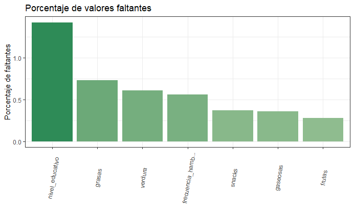

```r
tabla %>%
  filter(porcentaje_faltantes>0) %>%
  ggplot(., aes(x=reorder(Variables, -porcentaje_faltantes), y=porcentaje_faltantes, fill=porcentaje_faltantes)) +
  geom_bar(stat = "identity") +
  scale_fill_gradient(high = "seagreen", low = "darkseagreen") +
  scale_x_discrete(label = function(x) stringr::str_trunc(x, 18)) +
  theme_bw() +
  theme(axis.text.x = element_text(angle=80, vjust=0.5), legend.position = "none") +
  labs(title='Porcentaje de valores faltantes', y='Porcentaje de faltantes', x='')
```

### Eliminación de registros con valores faltantes

En total tenemos 304 valores faltantes, un 4.33% del total del set. Como se trata de un porcentaje pequeño se decide eliminar estos registros.

```r
sum(tabla$valores_faltantes) # cantidad total de faltantes
```

```
[1] 304
```

```r
sum(tabla$porcentaje_faltantes) # cantidad total de faltantes en %
```

```
[1] 4.33
```

```r
# Eliminamos los registros faltantes
ds_train<- ds_train[!(ds_train$nivel_educativo=="Dato perdido"), ]
ds_train<- ds_train[!(ds_train$grasas=="Dato perdido"), ]
ds_train<- ds_train[!(ds_train$verdura=="Dato perdido"), ]
ds_train<- ds_train[!(ds_train$frecuencia_hambre_mensual=="Dato perdido"), ]
ds_train<- ds_train[!(ds_train$snacks=="Dato perdido"), ]
ds_train<- ds_train[!(ds_train$gaseosas=="Dato perdido"), ]
ds_train<- ds_train[!(ds_train$frutas=="Dato perdido"), ]

# Chequeamos dimension del nuevo dataset
nrow(ds_train) #6755
```

```
[1] 6755
```

Luego de eliminar estos registros nos queda un dataset con 6755 observaciones de las 7024 originales, es decir, se eliminaron 269 observaciones.

### Buscamos correlaciones entre las 6 variables numéricas

```r
# Generamos un ds solo con las variables numéricas

numericas<- ds_train %>%
  select(edad, altura, peso, dias_consumo_comida_rapida, consumo_diario_alcohol, dias_actividad_fisica_semanal)

# Calculamos la matriz de correlación con ambos métodos

# Pearson
matriz.correl.pe <- numericas %>%
 correlate(use = "complete.obs", method = "pearson")
```

```
Correlation method: 'pearson'
Missing treated using: 'complete.obs'
```

```r
matriz.correl.pe %>%
  shave() %>%
  fashion()
```

| term | edad | altura | peso | dias_consumo_comida_rapida | consumo_diario_alcohol | dias_actividad_fisica_semanal |
| --- | --- | --- | --- | --- | --- | --- |
| edad |  |  |  |  |  |  |
| altura | .25 |  |  |  |  |  |
| peso | .28 | .58 |  |  |  |  |
| dias_consumo_comida_rapida | -.03 | -.06 | -.06 |  |  |  |
| consumo_diario_alcohol | .23 | .08 | .08 | .07 |  |  |
| dias_actividad_fisica_semanal | .01 | .14 | .06 | .02 | .05 |  |

```r
# Spearman
matriz.correl.sp <-numericas %>%
 correlate(use = "complete.obs", method = "spearman")
```

```
Correlation method: 'spearman'
Missing treated using: 'complete.obs'
```

```r
matriz.correl.sp %>%
  shave() %>%
  fashion()
```

| term | edad | altura | peso | dias_consumo_comida_rapida | consumo_diario_alcohol | dias_actividad_fisica_semanal |
| --- | --- | --- | --- | --- | --- | --- |
| edad |  |  |  |  |  |  |
| altura | .24 |  |  |  |  |  |
| peso | .29 | .59 |  |  |  |  |
| dias_consumo_comida_rapida | -.02 | -.05 | -.06 |  |  |  |
| consumo_diario_alcohol | .24 | .09 | .10 | .08 |  |  |
| dias_actividad_fisica_semanal | .00 | .15 | .09 | .02 | .05 |  |

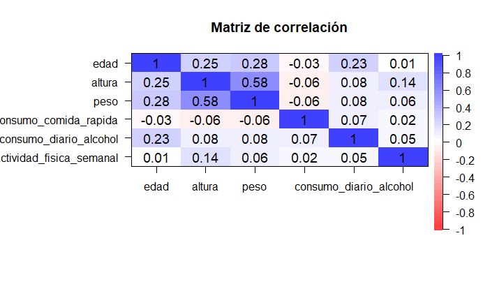

```r
# Gráficamente con Pearson
correlaciones<- cor(numericas)
corPlot(correlaciones, cex = 1.2, main = "Matriz de correlación")
```

Observamos que las variables más asociadas entre sí son *altura* y *peso* con 0.58 con método Pearson y 0.59 con Spearman. La asociación es positiva, por lo cual cuando crece una de las variables se espera que también crezca la otra; en otras palabras: A mayor altura, mayor peso, y viceversa.

**Veamos qué nos dicen los test. Aplicamos test de Pearson y Spearman (robusto):**

```r
#altura y peso
cor.test(ds_train$altura, ds_train$peso, method = "pearson")
```

```
    Pearson's product-moment correlation

data:  ds_train$altura and ds_train$peso
t = 57.986, df = 6753, p-value < 2.2e-16
alternative hypothesis: true correlation is not equal to 0
95 percent confidence interval:
 0.5604026 0.5922500
sample estimates:
      cor
0.5765452
```

```r
cor.test(ds_train$altura, ds_train$peso, method = "spearman")
```

```
Cannot compute exact p-value with ties
```

```
    Spearman's rank correlation rho

data:  ds_train$altura and ds_train$peso
S = 21274198272, p-value < 2.2e-16
alternative hypothesis: true rho is not equal to 0
sample estimates:
      rho
0.5858779
```

Notamos que la correlación entre *altura* y *peso* con el método de Spearman (0.585) es apenas más alta que con Pearson (0.576). No se hallan otras correlaciones entre *peso* y el resto de variables numéricas.

**Vemos asociación de variables realizando apertura por género**

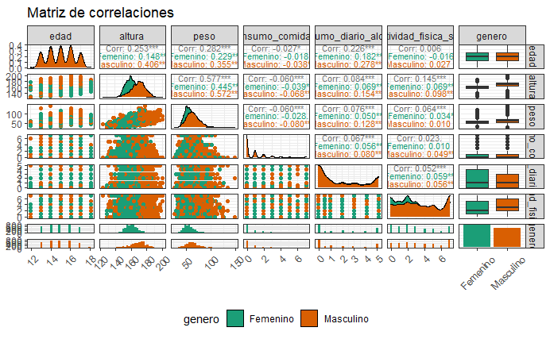

```r
# Usamos variables numéricas + "género"
numericas_gen<- ds_train %>%
  select(edad, altura, peso, dias_consumo_comida_rapida, consumo_diario_alcohol, dias_actividad_fisica_semanal, genero)

g<- ggpairs(numericas_gen,  mapping = aes(color = genero), title = "Matriz de correlaciones",
        upper = list(continuous = wrap("cor", size = 3, hjust=0.5)), legend = 25) +
  theme_bw() +
  theme(axis.text.x = element_text(angle=45, vjust=0.5), legend.position = "bottom")

for(i in 1:g$nrow) {
  for(j in 1:g$ncol){
    g[i,j] <- g[i,j] +
      scale_fill_brewer(palette="Dark2") +
      scale_color_brewer(palette="Dark2")}
}

g
```

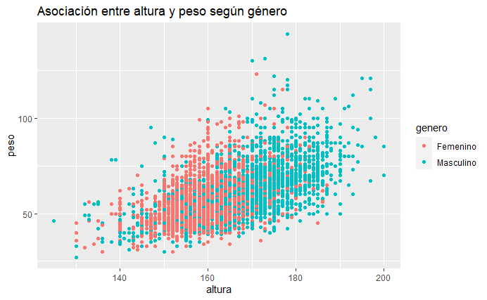

```r
# Observamos más de cerca la asociación entre altura y peso según género

ggplot(ds_train, aes(x = altura, y = peso, color = genero)) +
  geom_point() + labs(title="Asociación entre altura y peso según género")
```

Visualmente se observa la asociación lineal positiva entre nuestras variables, concentrandose en mayor medida en las menores alturas y pesos el género femenino y en las más grandes alturas y pesos el género masculino.

**Frecuencia de hambre mensual**

Para las categorías de la variable *frecuencia de hambre mensual*, analizamos gráficamente la distribución en términos de frecuencia relativa de: * a) El consumo semanal de verdura * b) El consumo semanal de comida grasa

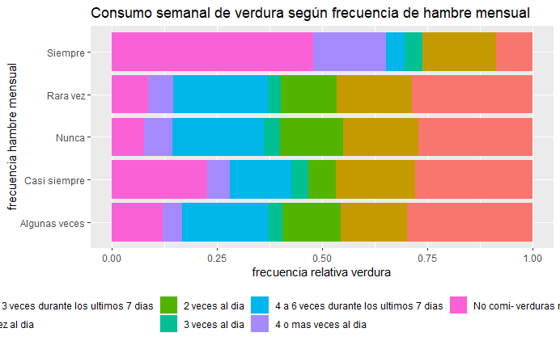

```r
ggplot(data = ds_train) +
  geom_bar(mapping = aes(x = frecuencia_hambre_mensual, fill = verdura), position = "fill")+
  theme(legend.position="bottom") +labs(title="Consumo semanal de verdura según frecuencia de hambre mensual",
        x ="frecuencia hambre mensual", y = "frecuencia relativa verdura")  + coord_flip()
```

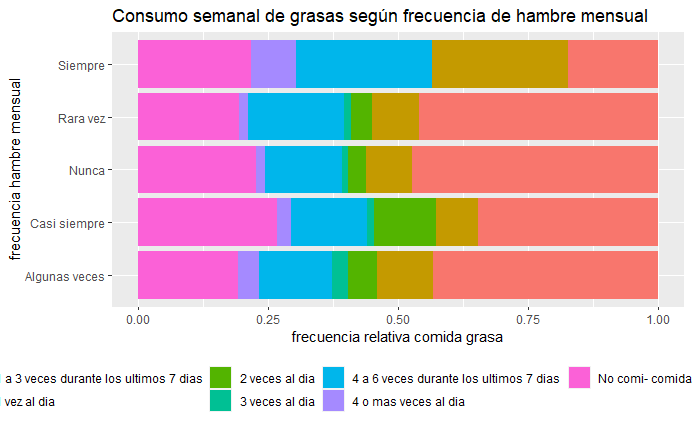

```r
ggplot(data = ds_train) +
  geom_bar(mapping = aes(x = frecuencia_hambre_mensual, fill = grasas), position = "fill") +
  theme(legend.position="bottom")+labs(title="Consumo semanal de grasas según frecuencia de hambre mensual",
        x ="frecuencia hambre mensual", y = "frecuencia relativa comida grasa") + coord_flip()
```

A partir de las gráficas expuestas podemos evidenciar que la mayoría de los estudiantes que siempre pasan hambre incorporan menos verduras en sus dietas que el resto, pero a su vez es dentro de este mismo grupo donde estudiantes ingieren por día más verduras. Los que casi siempre sienten hambre consumen verduras, en mayor medida, entre 1 y 3 veces por semana o directamente tampoco comen verduras. Hay un decrecimiento en la categoría “No comí verduras” a medida que la sensación de haber sentido hambre es menor, es decir que los que más pasan hambre consumieron menos verduras. Los que algunas veces sienten hambre, en mayor proporción, comen verduras entre 1 y 3 veces a la semana. A medida que menos sensación de hambre tienen, mayor es el consumo de verduras entre 4 a 6 veces semanalmente. En general hay poco consumo de verduras en todos los estudiantes en comparación a otros consumos.

## Modelo inicial

Para nuestro objetivo de explicar y predecir nuestra variable target *peso* se sugiere un primer Modelo Inicial, dado por:

E(peso) = β0+β1altura+β2edad+β3genero+β4diasActividadF isicaSemanal+β5consumoDiarioAlcohol

```r
# Ajustamos modelo lineal multiple
modelo_inicial <- lm(peso ~ altura + edad + genero + dias_actividad_fisica_semanal + consumo_diario_alcohol, data = ds_train)
# Resumen del modelo
tidy_sc_r <- tidy(modelo_inicial, conf.int = TRUE)
tidy_sc_r
```

| term | estimate | std.error | statistic | p.value | conf.low | conf.high |
| --- | --- | --- | --- | --- | --- | --- |
| (Intercept) | -68.924840224 | 2.38253736 | -28.9291750 | 1.413996e-173 | -73.5953653 | -64.2543151965 |
| altura | 0.653666837 | 0.01466302 | 44.5792639 | 0.000000e+00 | 0.6249227 | 0.6824109918 |
| edad | 1.378761653 | 0.09535841 | 14.4587312 | 1.095370e-46 | 1.1918291 | 1.5656942323 |
| generoMasculino | 1.224389872 | 0.27768320 | 4.4093049 | 1.053110e-05 | 0.6800432 | 1.7687365625 |
| dias_actividad_fisica_semanal | -0.099158550 | 0.05092770 | -1.9470456 | 5.157069e-02 | -0.1989929 | 0.0006758077 |
| consumo_diario_alcohol | 0.008569358 | 0.06257711 | 0.1369408 | 8.910817e-01 | -0.1141015 | 0.1312402300 |

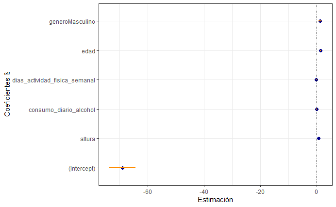

```r
# Plot de los coeficientes
ggplot(tidy_sc_r, aes(estimate, term, xmin = conf.low, xmax = conf.high, height = 0)) +
  geom_point(color = "darkblue",size=2) +
  geom_vline(xintercept = 0, lty = 4, color = "black") +
  geom_errorbarh(color = "darkorange", size=1) +
  theme_bw() +
  labs(y = "Coeficientes β", x = "Estimación")
```

**Interpretamos los coeficientes**

- Para este modelo lineal múltiple, orientado a predecir el peso en función de la altura, edad, el género, los días de actividad física semanal y el consumo diario de alcohol, notamos que el intercepto en este caso es negativo (-69 aproximadamente). Nuestro * $\beta_0$ (categoría basal de variable categórica) es la media del peso esperada para el **género femenino** sin altura, edad, días de actividad física semanal y consumo diario de alcohol. En este modelo, y para la variable *peso*, carece de sentido, ya que las mujeres deberían tener alguna edad y altura y no podrían tener un peso negativo.
- Para los estudiantes varones, respecto de las mujeres: Aumentar la altura de un estudiante en 1 cm aumenta el valor esperado del peso en 0.65kg, dado el resto de las variables del modelo. Aumentar la edad de un estudiante en 1 año aumenta el valor esperado del peso en 1.38kg, dado el resto de las variables del modelo. Aumentar la cantidad de actividad física semanal en un día disminuye el valor esperado del peso en 0.1kg, dado el resto de las variables del modelo.

**Chequeamos significatividad de las variables incluidas en el modelo**

```r
# Test T
options("scipen"=1)
tidy_sc_r %>%
  select(term, statistic, p.value, conf.low, conf.high)
```

| term | statistic | p.value | conf.low | conf.high |
| --- | --- | --- | --- | --- |
| (Intercept) | -28.9291750 | 1.413996e-173 | -73.5953653 | -64.2543151965 |
| altura | 44.5792639 | 0.000000e+00 | 0.6249227 | 0.6824109918 |
| edad | 14.4587312 | 1.095370e-46 | 1.1918291 | 1.5656942323 |
| generoMasculino | 4.4093049 | 1.053110e-05 | 0.6800432 | 1.7687365625 |
| dias_actividad_fisica_semanal | -1.9470456 | 5.157069e-02 | -0.1989929 | 0.0006758077 |
| consumo_diario_alcohol | 0.1369408 | 8.910817e-01 | -0.1141015 | 0.1312402300 |

```r
# Significatividad Test F para la variable género global
tidy(anova(modelo_inicial))
```

| term | df | sumsq | meansq | statistic | p.value |
| --- | --- | --- | --- | --- | --- |
| altura | 1 | 339618.46957 | 339618.46957 | 3474.66926765 | 0.000000e+00 |
| edad | 1 | 20295.22647 | 20295.22647 | 207.64241651 | 2.180260e-46 |
| genero | 1 | 1762.73379 | 1762.73379 | 18.03469918 | 2.198270e-05 |
| dias_actividad_fisica_semanal | 1 | 368.80540 | 368.80540 | 3.77328354 | 5.211885e-02 |
| consumo_diario_alcohol | 1 | 1.83292 | 1.83292 | 0.01875278 | 8.910817e-01 |
| Residuals | 6749 | 659655.60305 | 97.74124 | NA | NA |

La tabla de ANOVA muestra que, según el resultado del test F, la variable *género* en su conjunto resulta estadísticamente significativa para explicar al peso (p-valor < 0.05). Es decir, que pese a que algunas categorías en su comparación individual con la categoría basal sean poco significativas, la variable en su conjunto sí resulta significativa para el modelo.

## Modelo categóricas

En este modelo incorporamos el consumo semanal de snacks y una interacción entre el género y la edad, en lugar de actividad física y consumo de alcohol. Además, seleccionamos la categoría de snacks “No comí comida salada o snacks en los últimos 7 días” como basal. El modelo queda definido: * E(peso) = β0 + β1altura + β2edad + β3genero + β4consumoSemanalSnacks + β5genero · edad

```r
# Preparamos la respuesta “No comí comida salada o snacks en los últimos 7 días” como categoría basal, de forma no sofisticada
# Lo que se hace es modificar la nomenclatura del valor adicionando 1 1 delante para que quede primero en orden y R la tome como basal
 string_cleaning <- function(x){
 x <- gsub("No comi comida salada o snacks en los ultimos 7 dias", "1 1No comi snacks", x)
 return(x)
}
ds_train$snacks <- sapply(ds_train[,'snacks'],FUN = string_cleaning)


# Ajustamos modelo lineal multiple
modelo_cat <- lm(peso ~ altura + edad + genero + snacks + genero*edad, data = ds_train)
# Resumen del modelo
tidy_sc_cat <- tidy(modelo_cat, conf.int = TRUE)
tidy_sc_cat
```

| term | estimate | std.error | statistic | p.value | conf.low | conf.high |
| --- | --- | --- | --- | --- | --- | --- |
| (Intercept) | -64.6479875 | 2.87030372 | -22.523048 | 2.261394e-108 | -70.274689295 | -59.0212858 |
| altura | 0.6467154 | 0.01481585 | 43.650234 | 0.000000e+00 | 0.617671609 | 0.6757591 |
| edad | 1.2167591 | 0.12239655 | 9.941123 | 3.974656e-23 | 0.976823190 | 1.4566950 |
| generoMasculino | -4.0403437 | 2.72370910 | -1.483398 | 1.380155e-01 | -9.379673695 | 1.2989863 |
| snacks1 a 3 veces durante los ultimos 7 dias | -1.4368851 | 0.28028645 | -5.126488 | 3.034134e-07 | -1.986335069 | -0.8874352 |
| snacks1 vez al dia | -0.6565845 | 0.46383525 | -1.415555 | 1.569519e-01 | -1.565848025 | 0.2526791 |
| snacks2 veces al dia | -1.0608560 | 0.69485004 | -1.526741 | 1.268724e-01 | -2.422981482 | 0.3012696 |
| snacks3 veces al dia | -1.1903835 | 1.02955288 | -1.156214 | 2.476346e-01 | -3.208632258 | 0.8278653 |
| snacks4 a 6 veces durante los ultimos 7 dias | -2.2551628 | 0.45726634 | -4.931837 | 8.340962e-07 | -3.151549278 | -1.3587764 |
| snacks4 o mas veces al dia | -2.6018645 | 0.91604489 | -2.840324 | 4.520270e-03 | -4.397601785 | -0.8061272 |

[output cut: 1 more lines]

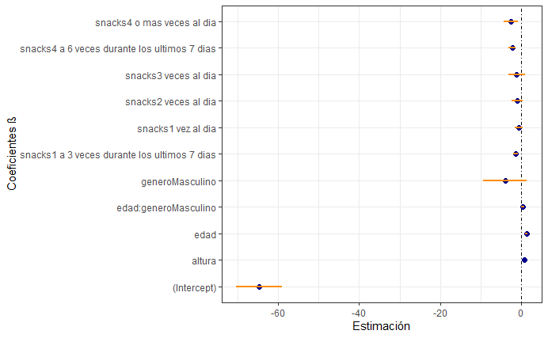

```r
ggplot(tidy_sc_cat, aes(estimate, term, xmin = conf.low, xmax = conf.high, height = 0)) +
  geom_point(color = "darkblue",size=2) +
  geom_vline(xintercept = 0, lty = 4, color = "black") +
  geom_errorbarh(color = "darkorange", size=1) +
  theme_bw() +
  labs(y = "Coeficientes β", x = "Estimación")
```

**Interpretamos los coeficientes**

- Observamos que los coeficientes de las categorías de *snacks* son negativos. Esto indica cuánto se reduce el peso medio de los estudiantes según la frecuencia con que consumen snacks respecto de aquellos que no comieron snacks en los últimos 7 días (categoría basal), dado el resto de variables involucradas en el modelo.
- El coeficiente de la interacción *edad/género masculino* indica que aumentar la *edad* de un estudiante *varón* en 1 año aumenta el valor **esperado** del peso en 0,35kg, dado el resto de las variables del modelo.

**Chequeamos significatividad de las variables incluidas en el modelo**

```r
options("scipen"=1)
tidy_sc_cat %>%
  select(term, statistic, p.value, conf.low, conf.high)
```

| term | statistic | p.value | conf.low | conf.high |
| --- | --- | --- | --- | --- |
| (Intercept) | -22.523048 | 2.261394e-108 | -70.274689295 | -59.0212858 |
| altura | 43.650234 | 0.000000e+00 | 0.617671609 | 0.6757591 |
| edad | 9.941123 | 3.974656e-23 | 0.976823190 | 1.4566950 |
| generoMasculino | -1.483398 | 1.380155e-01 | -9.379673695 | 1.2989863 |
| snacks1 a 3 veces durante los ultimos 7 dias | -5.126488 | 3.034134e-07 | -1.986335069 | -0.8874352 |
| snacks1 vez al dia | -1.415555 | 1.569519e-01 | -1.565848025 | 0.2526791 |
| snacks2 veces al dia | -1.526741 | 1.268724e-01 | -2.422981482 | 0.3012696 |
| snacks3 veces al dia | -1.156214 | 2.476346e-01 | -3.208632258 | 0.8278653 |
| snacks4 a 6 veces durante los ultimos 7 dias | -4.931837 | 8.340962e-07 | -3.151549278 | -1.3587764 |
| snacks4 o mas veces al dia | -2.840324 | 4.520270e-03 | -4.397601785 | -0.8061272 |

[output cut: 1 more lines]

- Cuando tomamos como categoría basal **“No comí comida salada o snacks en los últimos 7 días”** de la variable *snacks*, la variable **género masculino** deja de ser significativa (p-value=0,138), las categorías de snacks **1 vez al día**(p-value=0,16), **2 veces al día** (p-value=0,13) y **3 veces al día** (p-value=0,25) también dejan de ser significativas, al igual que la incorporación de la interacción entre *edad y género masculino*, no es significativa para predecir el peso (p-value = 0,055).
- Podemos observar que para estas mismas categorías el 0 está incluido en los intervalos de confianza, con lo cuál se refuerza más aún la no significatividad de las mismas en este modelo.

```r
# Significatividad Test F para la variable Snacks global
tidy(anova(modelo_cat))
```

| term | df | sumsq | meansq | statistic | p.value |
| --- | --- | --- | --- | --- | --- |
| altura | 1 | 339618.4696 | 339618.46957 | 3493.045417 | 0.000000e+00 |
| edad | 1 | 20295.2265 | 20295.22647 | 208.740555 | 1.278173e-46 |
| genero | 1 | 1762.7338 | 1762.73379 | 18.130078 | 2.091166e-05 |
| snacks | 6 | 3968.9005 | 661.48342 | 6.803492 | 3.302649e-07 |
| edad:genero | 1 | 358.1771 | 358.17710 | 3.683925 | 5.498154e-02 |
| Residuals | 6744 | 655699.1637 | 97.22704 | NA | NA |

- La variable *snacks* en conjunto es significativa para explicar el peso (p-value<0.05), mientras que la interacción entre *edad y género* global continúa no siendolo.

**Redefinición de categorías**

- Como algunas categorías de *snacks* no dan significativas individualmente, pero la variable es significativa de forma global, se crea una nueva variable `frec_snacks` que clasifica al consumo de snacks según la frecuencia de consumo en 3 grandes grupos: “**Nula** (es el no consumo, que se mantiene como basal), **media y alta**”.

```r
ds_train = ds_train %>%
  mutate(frec_snacks = case_when(snacks== "1 1No comi snacks" ~ "1 1Nula",
                                 snacks== "1 a 3 veces durante los ultimos 7 dias" ~ "media",
                                 snacks=="4 a 6 veces durante los ultimos 7 dias" ~ "media",
                                 snacks=="1 vez al dia" ~ "alta",
                                 snacks=="2 veces al dia" ~ "alta",
                                 snacks=="3 veces al dia" ~ "alta",
                                 snacks=="4 o mas veces al dia" ~ "alta"))

head(ds_train) # Observamos la nueva variable
```

|  | record | edad | genero | nivel_educativo | altura | peso | frecuencia_hambre_mensual | dias_consumo_comida_rapida | edad_consumo_alcohol | consumo_diario_alcohol | dias_actividad_fisica_semanal | frutas | verdura | gaseosas | snacks | grasas | frec_snacks |
| --- | --- | --- | --- | --- | --- | --- | --- | --- | --- | --- | --- | --- | --- | --- | --- | --- | --- |
| 1 | 502 | 17 | Femenino | 2do año/11vo grado nivel Polimodal o 4to año nivel Secundario | 165 | 62 | Rara vez | 0 | 14 o 15 años | 5 | 7 | No comi frutas durante los ultimos 7 dias | 4 a 6 veces durante los ultimos 7 dias | 1 a 3 veces durante los ultimos 7 dias | 1 a 3 veces durante los ultimos 7 dias | No comi comida alta en grasa en los ultimos 7 dias | media |
| 2 | 26488 | 15 | Masculino | 1er año/10mo grado nivel Polimodal o 3er año nivel Secundario | 178 | 62 | Rara vez | 0 | 7 años o menos | 4 | 7 | No comi frutas durante los ultimos 7 dias | 4 a 6 veces durante los ultimos 7 dias | 1 a 3 veces durante los ultimos 7 dias | 1 1No comi snacks | 4 a 6 veces durante los ultimos 7 dias | 1 1Nula |
| 3 | 31473 | 15 | Masculino | 2do año/11vo grado nivel Polimodal o 4to año nivel Secundario | 172 | 62 | Nunca | 3 | Nunca tome alcohol mas que unos pocos sorbos | 0 | 7 | No comi frutas durante los ultimos 7 dias | 1 vez al dia | 4 a 6 veces durante los ultimos 7 dias | 4 a 6 veces durante los ultimos 7 dias | No comi comida alta en grasa en los ultimos 7 dias | media |
| 4 | 14154 | 16 | Masculino | 1er año/10mo grado nivel Polimodal o 3er año nivel Secundario | 170 | 65 | Nunca | 1 | 14 o 15 años | 0 | 7 | 4 a 6 veces durante los ultimos 7 dias | 4 o mas veces al dia | 1 a 3 veces durante los ultimos 7 dias | 1 a 3 veces durante los ultimos 7 dias | No comi comida alta en grasa en los ultimos 7 dias | media |
| 5 | 36578 | 17 | Masculino | 2do año/11vo grado nivel Polimodal o 4to año nivel Secundario | 170 | 75 | Rara vez | 1 | 16 o 17 años | 0 | 0 | 2 veces al dia | 1 a 3 veces durante los ultimos 7 dias | 1 vez al dia | 1 1No comi snacks | 1 a 3 veces durante los ultimos 7 dias | 1 1Nula |
| 6 | 53730 | 15 | Masculino | 1er año/10mo grado nivel Polimodal o 3er año nivel Secundario | 178 | 88 | Nunca | 2 | 8 o 9 años | 5 | 7 | 1 vez al dia | 2 veces al dia | 4 a 6 veces durante los ultimos 7 dias | 4 a 6 veces durante los ultimos 7 dias | 4 a 6 veces durante los ultimos 7 dias | media |

```r
# Ajustamos nuevamente el modelo con la nueva variable
modelo_cat2 <- lm(peso ~ altura + edad + genero + frec_snacks + genero*edad, data = ds_train)
# Resumen del modelo
tidy_sc_cat2 <- tidy(modelo_cat2, conf.int = TRUE)
tidy_sc_cat2
```

| term | estimate | std.error | statistic | p.value | conf.low | conf.high |
| --- | --- | --- | --- | --- | --- | --- |
| (Intercept) | -64.6875902 | 2.8702761 | -22.537062 | 1.676320e-108 | -70.314237243 | -59.0609432 |
| altura | 0.6471433 | 0.0148146 | 43.682795 | 0.000000e+00 | 0.618101998 | 0.6761846 |
| edad | 1.2147793 | 0.1224141 | 9.923526 | 4.728901e-23 | 0.974809105 | 1.4547496 |
| generoMasculino | -4.0774421 | 2.7225619 | -1.497649 | 1.342712e-01 | -9.414522737 | 1.2596385 |
| frec_snacksalta | -1.0284468 | 0.3774528 | -2.724703 | 6.452511e-03 | -1.768373312 | -0.2885203 |
| frec_snacksmedia | -1.5715872 | 0.2708109 | -5.803265 | 6.798455e-09 | -2.102461916 | -1.0407124 |
| edad:generoMasculino | 0.3517157 | 0.1819604 | 1.932925 | 5.328723e-02 | -0.004984004 | 0.7084155 |

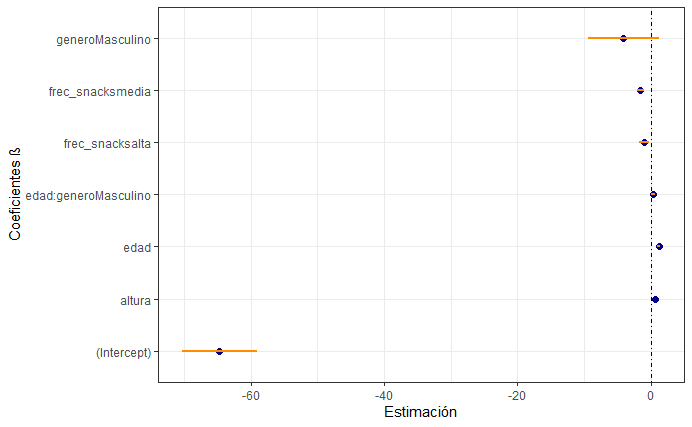

```r
ggplot(tidy_sc_cat2, aes(estimate, term, xmin = conf.low, xmax = conf.high, height = 0)) +
  geom_point(color = "darkblue",size=2) +
  geom_vline(xintercept = 0, lty = 4, color = "black") +
  geom_errorbarh(color = "darkorange", size=1) +
  theme_bw() +
  labs(y = "Coeficientes β", x = "Estimación")
```

**Rechequeamos significatividad de las variables**

```r
options("scipen"=1)
tidy_sc_cat2 %>%
  select(term, statistic, p.value, conf.low, conf.high)
```

| term | statistic | p.value | conf.low | conf.high |
| --- | --- | --- | --- | --- |
| (Intercept) | -22.537062 | 1.676320e-108 | -70.314237243 | -59.0609432 |
| altura | 43.682795 | 0.000000e+00 | 0.618101998 | 0.6761846 |
| edad | 9.923526 | 4.728901e-23 | 0.974809105 | 1.4547496 |
| generoMasculino | -1.497649 | 1.342712e-01 | -9.414522737 | 1.2596385 |
| frec_snacksalta | -2.724703 | 6.452511e-03 | -1.768373312 | -0.2885203 |
| frec_snacksmedia | -5.803265 | 6.798455e-09 | -2.102461916 | -1.0407124 |
| edad:generoMasculino | 1.932925 | 5.328723e-02 | -0.004984004 | 0.7084155 |

Notamos que con la recategorización de la variable *snacks* en *frec_snacks* nos entrega un modelo donde dichas categorías se vuelven significativas; tanto **frec_snacksmedia** como **frec_snacksalta** tienen un p-value<0.05. Sin embargo, en este modelo se mantiene la no significatividad de la categoría **Masculino** de la variable *género* y de su interacción con la variable *edad*.

**Variabilidad de los modelos**

```r
# armamos lista con todos los modelos
models <- list(modelo_inicial = modelo_inicial, modelo_cat = modelo_cat, modelo_cat2 = modelo_cat2)
```

Usamos R Ajustado para conocer la variabilidad explicada de los modelos

```r
# calculamos las métricas para todos los modelos
df_evaluacion_train = map_df(models, broom::glance, .id = "model") %>%
  # ordenamos por R2 ajustado
  arrange(desc(adj.r.squared))

df_evaluacion_train
```

| model | r.squared | adj.r.squared | sigma | statistic | p.value | df | logLik | AIC | BIC | deviance | df.residual | nobs |
| --- | --- | --- | --- | --- | --- | --- | --- | --- | --- | --- | --- | --- |
| modelo_cat | 0.3582290 | 0.3572774 | 9.860377 | 376.4421 | 0 | 10 | -25038.41 | 50100.82 | 50182.63 | 655699.2 | 6744 | 6755 |
| modelo_cat2 | 0.3575219 | 0.3569506 | 9.862884 | 625.8468 | 0 | 6 | -25042.13 | 50100.25 | 50154.80 | 656421.6 | 6748 | 6755 |
| modelo_inicial | 0.3543566 | 0.3538783 | 9.886417 | 740.8277 | 0 | 5 | -25058.73 | 50131.45 | 50179.18 | 659655.6 | 6749 | 6755 |

Notamos que el Modelo Inicial logra explicar un 35,39% aproximadamente de la variabilidad, mientras que el Modelo Categóricas logra explicar un poco más: 35,73%. El Modelo Categóricas 2 (**modelo_cat2**) con la redefinición de las categorías *snacks* y su posterior significatidad individual disminuye un poco la proporción de la variabilidad explicada (35,69%)

## Modelos propios y evaluación

Se realiza un primer modelo lineal múltiple del *peso* en función del resto de las variables solo para verificar variables y categorías significativas (para **este** modelo):

**Modelo Todas las variables**

```r
# Ajustamos modelo lineal multiple
modelo_todas_var <- lm(peso ~ ., data = ds_train)
# Resumen del modelo
tidy_sc_v <- tidy(modelo_todas_var, conf.int = TRUE)
```

**Chequeamos cuáles son las variables y categorías significativas incluidas en el modelo**

```r
# Filtramos varibles con un p-value menor a 0.05
options("scipen"=1)
tidy_sc_v %>%
  select(term, statistic, p.value, conf.low, conf.high) %>%
  filter(p.value<0.05)
```

| term | statistic | p.value | conf.low | conf.high |
| --- | --- | --- | --- | --- |
| (Intercept) | -23.306218 | 1.370371e-115 | -7.380449e+01 | -6.235216e+01 |
| record | 2.133037 | 3.295789e-02 | 1.305043e-06 | 3.092883e-05 |
| edad | 9.888821 | 6.675042e-23 | 1.090495e+00 | 1.629743e+00 |
| generoMasculino | 4.587078 | 4.576663e-06 | 7.384952e-01 | 1.840754e+00 |
| nivel_educativo2do año/11vo grado nivel Polimodal o 4to año nivel Secundario | -2.411847 | 1.589867e-02 | -1.570806e+00 | -1.622226e-01 |
| altura | 44.186150 | 0.000000e+00 | 6.237695e-01 | 6.816861e-01 |
| dias_actividad_fisica_semanal | -2.107666 | 3.509692e-02 | -2.111602e-01 | -7.648517e-03 |
| verdura1 vez al dia | -2.001598 | 4.536827e-02 | -1.487843e+00 | -1.550198e-02 |
| gaseosas2 veces al dia | -2.902419 | 3.715000e-03 | -2.423390e+00 | -4.695048e-01 |
| gaseosas4 o mas veces al dia | -3.015121 | 2.578387e-03 | -2.487206e+00 | -5.272927e-01 |

[output cut: 4 more lines]

**Y globalmente**

```r
# Significatividad Test F
tidy(anova(modelo_todas_var))
```

| term | df | sumsq | meansq | statistic | p.value |
| --- | --- | --- | --- | --- | --- |
| record | 1 | 404.05525 | 404.05525 | 4.1796197 | 4.095187e-02 |
| edad | 1 | 81324.49888 | 81324.49888 | 841.2351449 | 2.398712e-174 |
| genero | 1 | 85584.98730 | 85584.98730 | 885.3063983 | 7.802426e-183 |
| nivel_educativo | 4 | 3320.69139 | 830.17285 | 8.5874562 | 6.568324e-07 |
| altura | 1 | 192070.87586 | 192070.87586 | 1986.8154531 | 0.000000e+00 |
| frecuencia_hambre_mensual | 4 | 512.62956 | 128.15739 | 1.3256829 | 2.577435e-01 |
| dias_consumo_comida_rapida | 1 | 559.40276 | 559.40276 | 5.7865620 | 1.617606e-02 |
| edad_consumo_alcohol | 7 | 561.02489 | 80.14641 | 0.8290488 | 5.629320e-01 |
| consumo_diario_alcohol | 1 | 10.72263 | 10.72263 | 0.1109168 | 7.391132e-01 |
| dias_actividad_fisica_semanal | 1 | 385.67839 | 385.67839 | 3.9895262 | 4.582429e-02 |

[output cut: 6 more lines]

**Modelo propio 1: E(peso) = β0+β1altura+β2edad+β3genero+β4diasActividadF isicaSemanal+β5frecuencia_hambre_mensual+β6grasas+β7verdura**

Agregamos algunas de las variables del Modelo Inicial más *frecuencia_hambre_mensual*, *grasas* y *verdura*, que se analizaron más arriba con mayor profundidad y se encontraron relaciones interesantes.

```r
# Ajustamos modelo lineal multiple
modelo_mp1 <- lm(peso ~  altura + edad + genero + dias_actividad_fisica_semanal + frecuencia_hambre_mensual + grasas + verdura , data = ds_train)
# Resumen del modelo
tidy_sc_mp1 <- tidy(modelo_mp1, conf.int = TRUE)

tidy_sc_mp1 # Vemos los coeficientes
```

| term | estimate | std.error | statistic | p.value | conf.low | conf.high |
| --- | --- | --- | --- | --- | --- | --- |
| (Intercept) | -69.61290025 | 2.40837014 | -28.90456879 | 2.800064e-173 | -74.3340676 | -64.891732944 |
| altura | 0.65655083 | 0.01469744 | 44.67110144 | 0.000000e+00 | 0.6277392 | 0.685362463 |
| edad | 1.39060315 | 0.09345125 | 14.88051966 | 2.661546e-49 | 1.2074091 | 1.573797164 |
| generoMasculino | 1.21681804 | 0.27742844 | 4.38606089 | 1.171795e-05 | 0.6729705 | 1.760665549 |
| dias_actividad_fisica_semanal | -0.10312160 | 0.05125671 | -2.01186536 | 4.427389e-02 | -0.2036010 | -0.002642234 |
| frecuencia_hambre_mensualCasi siempre | 0.67418129 | 1.21497300 | 0.55489405 | 5.789856e-01 | -1.7075501 | 3.055912711 |
| frecuencia_hambre_mensualNunca | 0.65411660 | 0.43932444 | 1.48891465 | 1.365567e-01 | -0.2070983 | 1.515331482 |
| frecuencia_hambre_mensualRara vez | 0.12556854 | 0.49174839 | 0.25535120 | 7.984597e-01 | -0.8384139 | 1.089550932 |
| frecuencia_hambre_mensualSiempre | 1.64915886 | 2.11048489 | 0.78141230 | 4.345875e-01 | -2.4880591 | 5.786376863 |
| grasas1 vez al dia | 1.15725884 | 0.44056909 | 2.62673634 | 8.640335e-03 | 0.2936041 | 2.020913627 |

[output cut: 11 more lines]

- A grandes rasgos vemos que para este modelo, y siempre en función del resto de variables involucradas, el **peso esperado** aumenta con la *altura*, la *edad* y si el *género* es **masculino**. Disminuye con los *días de actividad física* y consumo de *verduras*. Con *grasas* y *frecuencia hambre mensual* no se obtienen resultados tan esperados.

**Significatividad individual**

```r
# filtramos por las categorías que son significativas en el modelo
options("scipen"=1)
tidy_sc_mp1 %>%
  select(term, statistic, p.value, conf.low, conf.high)%>%
  filter(p.value<0.05)
```

| term | statistic | p.value | conf.low | conf.high |
| --- | --- | --- | --- | --- |
| (Intercept) | -28.904569 | 2.800064e-173 | -74.3340676 | -64.891732944 |
| altura | 44.671101 | 0.000000e+00 | 0.6277392 | 0.685362463 |
| edad | 14.880520 | 2.661546e-49 | 1.2074091 | 1.573797164 |
| generoMasculino | 4.386061 | 1.171795e-05 | 0.6729705 | 1.760665549 |
| dias_actividad_fisica_semanal | -2.011865 | 4.427389e-02 | -0.2036010 | -0.002642234 |
| grasas1 vez al dia | 2.626736 | 8.640335e-03 | 0.2936041 | 2.020913627 |
| grasas2 veces al dia | -2.238975 | 2.519004e-02 | -2.6990442 | -0.179104812 |
| grasas4 a 6 veces durante los ultimos 7 dias | -2.389811 | 1.688439e-02 | -1.5375845 | -0.151807961 |

Vemos que las categorías de *frecuencia hambre mensual* y *verdura* no son significativas individualmente.

**Significatividad global**

```r
# Significatividad Test F
tidy(anova(modelo_mp1))
```

| term | df | sumsq | meansq | statistic | p.value |
| --- | --- | --- | --- | --- | --- |
| altura | 1 | 339618.4696 | 339618.46957 | 3483.4090014 | 0.000000e+00 |
| edad | 1 | 20295.2265 | 20295.22647 | 208.1646934 | 1.696164e-46 |
| genero | 1 | 1762.7338 | 1762.73379 | 18.0800613 | 2.146714e-05 |
| dias_actividad_fisica_semanal | 1 | 368.8054 | 368.80540 | 3.7827744 | 5.182430e-02 |
| frecuencia_hambre_mensual | 4 | 532.9661 | 133.24152 | 1.3666356 | 2.428111e-01 |
| grasas | 6 | 2059.0002 | 343.16670 | 3.5198026 | 1.766054e-03 |
| verdura | 6 | 527.3563 | 87.89271 | 0.9015006 | 4.925916e-01 |
| Residuals | 6734 | 656538.1134 | 97.49601 | NA | NA |

**Creamos nuevas variables a partir de otras variables del dataset para buscar mayor proporción de significatividad individual de sus categorías o mayor variabilidad explicada**

```r
ds_train = ds_train %>% # Nueva variable frec_grasas (Nula, media y alta)
  mutate(frec_grasas = case_when(grasas== "No comi comida alta en grasa en los ultimos 7 dias" ~ "1 1Nula", # Pasa a cat. basal
                                 grasas== "1 a 3 veces durante los ultimos 7 dias"  ~ "media",
                                 grasas=="4 a 6 veces durante los ultimos 7 dias" ~ "media",
                                 grasas=="1 vez al dia" ~ "alta",
                                 grasas=="2 veces al dia" ~ "alta",
                                 grasas=="3 veces al dia" ~ "alta",
                                 grasas=="4 o mas veces al dia" ~ "alta"))

ds_train = ds_train %>% # Nueva variable frec_frutas (Nula, media y alta)
  mutate(frec_frutas = case_when(frutas== "No comi frutas durante los ultimos 7 dias" ~ "1 1Nula", # Pasa a cat. basal
                                 frutas== "1 a 3 veces durante los ultimos 7 dias"  ~ "media",
                                 frutas=="4 a 6 veces durante los ultimos 7 dias" ~ "media",
                                 frutas=="1 vez al dia" ~ "alta",
                                 frutas=="2 veces al dia" ~ "alta",
                                 frutas=="3 veces al dia" ~ "alta",
                                 frutas=="4 o mas veces al dia" ~ "alta"))

ds_train = ds_train %>% # Nueva variable frec_gaseosas (Nula, media y alta)
  mutate(frec_gaseosas = case_when(gaseosas== "No tome gaseosas en los ultimos 7 dias" ~ "1 1Nula", # Pasa a cat. basal
                                 gaseosas== "1 a 3 veces durante los ultimos 7 dias"  ~ "media",
                                 gaseosas=="4 a 6 veces durante los ultimos 7 dias" ~ "media",
                                 gaseosas=="1 vez al dia" ~ "alta",
                                 gaseosas=="2 veces al dia" ~ "alta",
                                 gaseosas=="3 veces al dia" ~ "alta",
                                 gaseosas=="4 o mas veces al dia" ~ "alta"))

ds_train = ds_train %>% # Nueva variable frec_verdura (Nula, media y alta)
  mutate(frec_verdura = case_when(verdura== "No comi verduras ni hortalizas durante los ultimos 7 dias" ~ "1 1Nula", # Pasa a cat. basal
                                 verdura== "1 a 3 veces durante los ultimos 7 dias"  ~ "media",
                                 verdura=="4 a 6 veces durante los ultimos 7 dias" ~ "media",
                                 verdura=="1 vez al dia" ~ "alta",
                                 verdura=="2 veces al dia" ~ "alta",
                                 verdura=="3 veces al dia" ~ "alta",
                                 verdura=="4 o mas veces al dia" ~ "alta"))

ds_train = ds_train %>% # Nueva variable frec_hambre (Nula, media y alta)
  mutate(frec_hambre = case_when(frecuencia_hambre_mensual== "Nunca" ~ "1 1Nula", # Pasa a cat. basal
                                 frecuencia_hambre_mensual== "Rara vez"  ~ "media",
                                 frecuencia_hambre_mensual=="Algunas veces" ~ "media",
                                 frecuencia_hambre_mensual=="Casi siempre" ~ "alta",
                                 frecuencia_hambre_mensual=="Siempre" ~ "alta"))


head(ds_train) # Observamos las nuevas variables
```

|  | record | edad | genero | nivel_educativo | altura | peso | frecuencia_hambre_mensual | dias_consumo_comida_rapida | edad_consumo_alcohol | consumo_diario_alcohol | dias_actividad_fisica_semanal | frutas | verdura | gaseosas | snacks | grasas | frec_snacks | frec_grasas | frec_frutas | frec_gaseosas | frec_verdura | frec_hambre |
| --- | --- | --- | --- | --- | --- | --- | --- | --- | --- | --- | --- | --- | --- | --- | --- | --- | --- | --- | --- | --- | --- | --- |
| 1 | 502 | 17 | Femenino | 2do año/11vo grado nivel Polimodal o 4to año nivel Secundario | 165 | 62 | Rara vez | 0 | 14 o 15 años | 5 | 7 | No comi frutas durante los ultimos 7 dias | 4 a 6 veces durante los ultimos 7 dias | 1 a 3 veces durante los ultimos 7 dias | 1 a 3 veces durante los ultimos 7 dias | No comi comida alta en grasa en los ultimos 7 dias | media | 1 1Nula | 1 1Nula | media | media | media |
| 2 | 26488 | 15 | Masculino | 1er año/10mo grado nivel Polimodal o 3er año nivel Secundario | 178 | 62 | Rara vez | 0 | 7 años o menos | 4 | 7 | No comi frutas durante los ultimos 7 dias | 4 a 6 veces durante los ultimos 7 dias | 1 a 3 veces durante los ultimos 7 dias | 1 1No comi snacks | 4 a 6 veces durante los ultimos 7 dias | 1 1Nula | media | 1 1Nula | media | media | media |
| 3 | 31473 | 15 | Masculino | 2do año/11vo grado nivel Polimodal o 4to año nivel Secundario | 172 | 62 | Nunca | 3 | Nunca tome alcohol mas que unos pocos sorbos | 0 | 7 | No comi frutas durante los ultimos 7 dias | 1 vez al dia | 4 a 6 veces durante los ultimos 7 dias | 4 a 6 veces durante los ultimos 7 dias | No comi comida alta en grasa en los ultimos 7 dias | media | 1 1Nula | 1 1Nula | media | alta | 1 1Nula |
| 4 | 14154 | 16 | Masculino | 1er año/10mo grado nivel Polimodal o 3er año nivel Secundario | 170 | 65 | Nunca | 1 | 14 o 15 años | 0 | 7 | 4 a 6 veces durante los ultimos 7 dias | 4 o mas veces al dia | 1 a 3 veces durante los ultimos 7 dias | 1 a 3 veces durante los ultimos 7 dias | No comi comida alta en grasa en los ultimos 7 dias | media | 1 1Nula | media | media | alta | 1 1Nula |
| 5 | 36578 | 17 | Masculino | 2do año/11vo grado nivel Polimodal o 4to año nivel Secundario | 170 | 75 | Rara vez | 1 | 16 o 17 años | 0 | 0 | 2 veces al dia | 1 a 3 veces durante los ultimos 7 dias | 1 vez al dia | 1 1No comi snacks | 1 a 3 veces durante los ultimos 7 dias | 1 1Nula | media | alta | alta | media | media |
| 6 | 53730 | 15 | Masculino | 1er año/10mo grado nivel Polimodal o 3er año nivel Secundario | 178 | 88 | Nunca | 2 | 8 o 9 años | 5 | 7 | 1 vez al dia | 2 veces al dia | 4 a 6 veces durante los ultimos 7 dias | 4 a 6 veces durante los ultimos 7 dias | 4 a 6 veces durante los ultimos 7 dias | media | media | alta | media | alta | 1 1Nula |

**Modelo propio 2: β0+β1altura+β2edad+β3genero+β4frec_hambre+β5dias_consumo_comida_rapida+β6frec_grasas+β7frec_verdura+β7frec_snacks+β7frec_gaseosas+β7frec_frutas**

A partir de lo planteado en el modelo anterior se crea este nuevo modelo con las variables redefinidas

```r
# Ajustamos modelo lineal multiple
modelo_mp2 <- lm(peso ~  altura + edad + genero + frec_hambre + dias_consumo_comida_rapida +frec_grasas + frec_verdura + frec_snacks + frec_gaseosas + frec_frutas, data = ds_train)
# Resumen del modelo
tidy_sc_mp2 <- tidy(modelo_mp2, conf.int = TRUE)

tidy_sc_mp2 # Vemos los coeficientes
```

| term | estimate | std.error | statistic | p.value | conf.low | conf.high |
| --- | --- | --- | --- | --- | --- | --- |
| (Intercept) | -66.93299267 | 2.42946954 | -27.55045558 | 2.013513e-158 | -71.69552097 | -62.17046436 |
| altura | 0.64931343 | 0.01461410 | 44.43061136 | 0.000000e+00 | 0.62066518 | 0.67796169 |
| edad | 1.37062351 | 0.09346986 | 14.66380219 | 5.991308e-48 | 1.18739304 | 1.55385398 |
| generoMasculino | 1.22534149 | 0.27644003 | 4.43257618 | 9.458956e-06 | 0.68343165 | 1.76725134 |
| frec_hambrealta | -0.16209653 | 1.01406117 | -0.15984887 | 8.730049e-01 | -2.14997700 | 1.82578393 |
| frec_hambremedia | -0.60752538 | 0.26619282 | -2.28227564 | 2.250410e-02 | -1.12934745 | -0.08570331 |
| dias_consumo_comida_rapida | -0.15037843 | 0.09149199 | -1.64362403 | 1.003005e-01 | -0.32973165 | 0.02897479 |
| frec_grasasalta | 0.82622743 | 0.42873754 | 1.92711707 | 5.400704e-02 | -0.01423368 | 1.66668853 |
| frec_grasasmedia | 0.11141052 | 0.31147450 | 0.35768745 | 7.205884e-01 | -0.49917797 | 0.72199901 |
| frec_verduraalta | 0.04401372 | 0.45851037 | 0.09599285 | 9.235291e-01 | -0.85481156 | 0.94283899 |

[output cut: 7 more lines]

**Evaluación de modelos**

Levanto el dataset de testeo

```r
ds_test<- read.csv("encuesta_salud_test.csv")

glimpse(ds_test)
```

```
Rows: 3,011
Columns: 16
$ record                        <int> 15533, 21281, 56944, 48702, 13295, 5827, 13152, 10516, 17583,~
$ edad                          <int> 17, 14, 15, 15, 14, 15, 13, 13, 13, 16, 16, 14, 16, 15, 16, 1~
$ genero                        <chr> "Masculino", "Masculino", "Masculino", "Masculino", "Femenino~
$ nivel_educativo               <chr> "1er aÃ±o/10mo grado nivel Polimodal o 3er aÃ±o nivel Secunda~
$ altura                        <dbl> 180, 156, 168, 179, 153, 157, 170, 163, 154, 170, 170, 176, 1~
$ peso                          <int> 86, 54, 56, 64, 52, 52, 50, 47, 58, 55, 60, 66, 89, 54, 58, 4~
$ frecuencia_hambre_mensual     <chr> "Nunca", "Rara vez", "Nunca", "Algunas veces", "Rara vez", "N~
$ dias_consumo_comida_rapida    <int> 0, 1, 1, 0, 0, 0, 0, 0, 0, 0, 0, 0, 0, 3, 0, 0, 0, 0, 1, 0, 0~
$ edad_consumo_alcohol          <chr> "12 o 13 aÃ±os", "14 o 15 aÃ±os", "12 o 13 aÃ±os", "10 o 11 a~
$ consumo_diario_alcohol        <dbl> 5.0, 0.0, 1.0, 5.0, 0.5, 3.0, 0.0, 1.0, 0.0, 0.0, 0.0, 0.0, 2~
$ dias_actividad_fisica_semanal <int> 1, 7, 1, 1, 3, 3, 0, 6, 3, 1, 5, 4, 3, 7, 4, 0, 1, 2, 7, 1, 1~
$ consumo_semanal_frutas        <chr> "2 veces al dÃa", "4 o mÃ¡s veces al dÃa", "1 vez al dÃa",~
$ consumo_semanal_verdura       <chr> "1 a 3 veces durante los Ãºltimos 7 dÃas", "Dato perdido", "~
$ consumo_semanal_gaseosas      <chr> "1 a 3 veces durante los Ãºltimos 7 dÃas", "4 o mÃ¡s veces a~
$ consumo_semanal_snacks        <chr> "No comÃ comida salada o snacks en los Ãºltimos 7 dÃas", "1~
$ consumo_semanal_comida_grasa  <chr> "No comÃ comida alta en grasa en los Ãºltimos 7 dÃas", "1 a~
```

Hacemos el mismo feature engineering de *ds_train* para el dataset de *test*, para poder aplicar los modelos que fueron entrenados en train, en test.

```r
# Limpiamos un poco las variables con string
string_cleaning <- function(x){
  x <- gsub("aÃ±o", "año", x)
  x <- gsub("tomÃ©", "tome", x)
  x <- gsub("mÃ¡s", "mas", x)
  x <- gsub("comÃ", "comi", x)
  x <- gsub("Ãºltimo", "ultimo", x)
  x <-gsub("dÃa", "dia", x)
  x <- gsub("No comi comida salada o snacks en los ultimos 7 dias", "1 1No comi snacks", x)
  #x <- gsub("Dato perdido", "", x)
  return(x)
}

#aplicamos función a 'ds_train$nivel_educativo'
ds_test$nivel_educativo <- sapply(ds_test[,'nivel_educativo'],FUN = string_cleaning)

#aplicamos función a 'ds_train$edad_consumo_alcohol'
ds_test$edad_consumo_alcohol <- sapply(ds_test[,'edad_consumo_alcohol'],FUN = string_cleaning)

#aplicamos función a 'ds_train$consumo_semanal_frutas'
ds_test$consumo_semanal_frutas <- sapply(ds_test[,'consumo_semanal_frutas'],FUN = string_cleaning)

#aplicamos función a 'ds_train$consumo_semanal_verdura'
ds_test$consumo_semanal_verdura <- sapply(ds_test[,'consumo_semanal_verdura'],FUN = string_cleaning)

#aplicamos función a 'ds_train$consumo_semanal_gaseosas'
ds_test$consumo_semanal_gaseosas <- sapply(ds_test[,'consumo_semanal_gaseosas'],FUN = string_cleaning)

#aplicamos función a 'ds_train$consumo_semanal_snacks'
ds_test$consumo_semanal_snacks <- sapply(ds_test[,'consumo_semanal_snacks'],FUN = string_cleaning)

#aplicamos función a 'ds_train$consumo_semanal_comida_grasa'
ds_test$consumo_semanal_comida_grasa <- sapply(ds_test[,'consumo_semanal_comida_grasa'],FUN = string_cleaning)


# Acortamos los nombres de las variables de consumo semanal

names(ds_test)[names(ds_test) == 'consumo_semanal_frutas'] <- 'frutas'
names(ds_test)[names(ds_test) == 'consumo_semanal_verdura'] <- 'verdura'
names(ds_test)[names(ds_test) == 'consumo_semanal_gaseosas'] <- 'gaseosas'
names(ds_test)[names(ds_test) == 'consumo_semanal_snacks'] <- 'snacks'
names(ds_test)[names(ds_test) == 'consumo_semanal_comida_grasa'] <- 'grasas'

ds_test$snacks <- sapply(ds_test[,'snacks'],FUN = string_cleaning)

# Generamos las mismas nuevas variables

ds_test = ds_test %>%
  mutate(frec_snacks = case_when(snacks== "No comi comida salada o snacks en los ultimos 7 dias" ~ "1 1Nula", # Pasa a cat. basal
                                 snacks== "1 a 3 veces durante los ultimos 7 dias" ~ "media",
                                 snacks=="4 a 6 veces durante los ultimos 7 dias" ~ "media",
                                 snacks=="1 vez al dia" ~ "alta",
                                 snacks=="2 veces al dia" ~ "alta",
                                 snacks=="3 veces al dia" ~ "alta",
                                 snacks=="4 o mas veces al dia" ~ "alta"))


ds_test = ds_test %>% # Nueva variable frec_grasas (Nula, media y alta)
  mutate(frec_grasas = case_when(grasas== "No comi comida alta en grasa en los ultimos 7 dias" ~ "1 1Nula", # Pasa a cat. basal
                                 grasas== "1 a 3 veces durante los ultimos 7 dias"  ~ "media",
                                 grasas=="4 a 6 veces durante los ultimos 7 dias" ~ "media",
                                 grasas=="1 vez al dia" ~ "alta",
                                 grasas=="2 veces al dia" ~ "alta",
                                 grasas=="3 veces al dia" ~ "alta",
                                 grasas=="4 o mas veces al dia" ~ "alta"))

ds_test = ds_test %>% # Nueva variable frec_frutas (Nula, media y alta)
  mutate(frec_frutas = case_when(frutas== "No comi frutas durante los ultimos 7 dias" ~ "1 1Nula", # Pasa a cat. basal
                                 frutas== "1 a 3 veces durante los ultimos 7 dias"  ~ "media",
                                 frutas=="4 a 6 veces durante los ultimos 7 dias" ~ "media",
                                 frutas=="1 vez al dia" ~ "alta",
                                 frutas=="2 veces al dia" ~ "alta",
                                 frutas=="3 veces al dia" ~ "alta",
                                 frutas=="4 o mas veces al dia" ~ "alta"))

ds_test = ds_test %>% # Nueva variable frec_gaseosas (Nula, media y alta)
  mutate(frec_gaseosas = case_when(gaseosas== "No tome gaseosas en los ultimos 7 dias" ~ "1 1Nula", # Pasa a cat. basal
                                 gaseosas== "1 a 3 veces durante los ultimos 7 dias"  ~ "media",
                                 gaseosas=="4 a 6 veces durante los ultimos 7 dias" ~ "media",
                                 gaseosas=="1 vez al dia" ~ "alta",
                                 gaseosas=="2 veces al dia" ~ "alta",
                                 gaseosas=="3 veces al dia" ~ "alta",
                                 gaseosas=="4 o mas veces al dia" ~ "alta"))

ds_test = ds_test %>% # Nueva variable frec_verdura (Nula, media y alta)
  mutate(frec_verdura = case_when(verdura== "No comi verduras ni hortalizas durante los ultimos 7 dias" ~ "1 1Nula", # Pasa a cat. basal
                                 verdura== "1 a 3 veces durante los ultimos 7 dias"  ~ "media",
                                 verdura=="4 a 6 veces durante los ultimos 7 dias" ~ "media",
                                 verdura=="1 vez al dia" ~ "alta",
                                 verdura=="2 veces al dia" ~ "alta",
                                 verdura=="3 veces al dia" ~ "alta",
                                 verdura=="4 o mas veces al dia" ~ "alta"))

ds_test = ds_test %>% # Nueva variable frec_hambre (Nula, media y alta)
  mutate(frec_hambre = case_when(frecuencia_hambre_mensual== "Nunca" ~ "1 1Nula", # Pasa a cat. basal
                                 frecuencia_hambre_mensual== "Rara vez"  ~ "media",
                                 frecuencia_hambre_mensual=="Algunas veces" ~ "media",
                                 frecuencia_hambre_mensual=="Casi siempre" ~ "alta",
                                 frecuencia_hambre_mensual=="Siempre" ~ "alta"))
```

Se trata de un dataset de 3011 observaciones (menos que en train) con 16 variables (o preguntas de la encuesta) que lo componen más las 6 nuevas creadas.

```r
dim(ds_test)
```

```
[1] 3011   22
```

```r
# Vemos cómo quedó el head de nuestro dataset

head(ds_test)
```

|  | record | edad | genero | nivel_educativo | altura | peso | frecuencia_hambre_mensual | dias_consumo_comida_rapida | edad_consumo_alcohol | consumo_diario_alcohol | dias_actividad_fisica_semanal | frutas | verdura | gaseosas | snacks | grasas | frec_snacks | frec_grasas | frec_frutas | frec_gaseosas | frec_verdura | frec_hambre |
| --- | --- | --- | --- | --- | --- | --- | --- | --- | --- | --- | --- | --- | --- | --- | --- | --- | --- | --- | --- | --- | --- | --- |
| 1 | 15533 | 17 | Masculino | 1er año/10mo grado nivel Polimodal o 3er año nivel Secundario | 180 | 86 | Nunca | 0 | 12 o 13 años | 5.0 | 1 | 2 veces al dia | 1 a 3 veces durante los ultimos 7 dias | 1 a 3 veces durante los ultimos 7 dias | 1 1No comi snacks | No comi comida alta en grasa en los ultimos 7 dias | NA | 1 1Nula | alta | media | media | 1 1Nula |
| 2 | 21281 | 14 | Masculino | 9no grado nivel Primario/Polimodal o 2do año nivel Secundario | 156 | 54 | Rara vez | 1 | 14 o 15 años | 0.0 | 7 | 4 o mas veces al dia | Dato perdido | 4 o mas veces al dia | 1 vez al dia | 1 a 3 veces durante los ultimos 7 dias | alta | media | alta | alta | NA | media |
| 3 | 56944 | 15 | Masculino | 1er año/10mo grado nivel Polimodal o 3er año nivel Secundario | 168 | 56 | Nunca | 1 | 12 o 13 años | 1.0 | 1 | 1 vez al dia | 1 vez al dia | 2 veces al dia | 1 a 3 veces durante los ultimos 7 dias | 4 a 6 veces durante los ultimos 7 dias | media | media | alta | alta | alta | 1 1Nula |
| 4 | 48702 | 15 | Masculino | 1er año/10mo grado nivel Polimodal o 3er año nivel Secundario | 179 | 64 | Algunas veces | 0 | 10 o 11 años | 5.0 | 1 | No comi frutas durante los ultimos 7 dias | 4 a 6 veces durante los ultimos 7 dias | No tome gaseosas en los ultimos 7 dias | 1 a 3 veces durante los ultimos 7 dias | 1 a 3 veces durante los ultimos 7 dias | media | media | 1 1Nula | 1 1Nula | media | media |
| 5 | 13295 | 14 | Femenino | 3er año/12vo grado nivel Polimodal o 5to año nivel Secundario | 153 | 52 | Rara vez | 0 | 7 años o menos | 0.5 | 3 | 2 veces al dia | 4 a 6 veces durante los ultimos 7 dias | 1 vez al dia | 1 1No comi snacks | 1 vez al dia | NA | alta | alta | alta | media | media |
| 6 | 5827 | 15 | Femenino | 1er año/10mo grado nivel Polimodal o 3er año nivel Secundario | 157 | 52 | Nunca | 0 | 14 o 15 años | 3.0 | 3 | 1 a 3 veces durante los ultimos 7 dias | 4 a 6 veces durante los ultimos 7 dias | 4 a 6 veces durante los ultimos 7 dias | 1 a 3 veces durante los ultimos 7 dias | 1 a 3 veces durante los ultimos 7 dias | media | media | media | media | media | 1 1Nula |

**Pasamos a NA los registros faltantes** Estos registros no se eliminan porque se trata del dataset donde vamos a probar los datos, ya no estamos entrenando.

```r
ds_test$nivel_educativo[ds_test$nivel_educativo=="Dato perdido"] <- NA
ds_test$grasas[ds_test$grasas=="Dato perdido"] <- NA
ds_test$verdura[ds_test$verdura=="Dato perdido"] <- NA
ds_test$frecuencia_hambre_mensual[ds_test$frecuencia_hambre_mensual=="Dato perdido"] <- NA
ds_test$snacks[ds_test$snacks=="Dato perdido"] <- NA
ds_test$gaseosas[ds_test$gaseosas=="Dato perdido"] <- NA
ds_test$frutas[ds_test$frutas=="Dato perdido"] <- NA
```

### Comparación entre training y testing

**Generamos una lista con todos los modelos realizados para poder evaluarlos**

```r
# armamos lista con todos los modelos
models <- list(modelo_inicial = modelo_inicial, modelo_cat = modelo_cat, modelo_cat2 = modelo_cat2, modelo_mp1 = modelo_mp1, modelo_mp2 = modelo_mp2)
# calculamos las variables resumen
purrr::map_df(models, broom::tidy, .id = "model")
```

| model | term | estimate | std.error | statistic | p.value |
| --- | --- | --- | --- | --- | --- |
| modelo_inicial | (Intercept) | -68.924840224 | 2.38253736 | -28.92917499 | 1.413996e-173 |
| modelo_inicial | altura | 0.653666837 | 0.01466302 | 44.57926386 | 0.000000e+00 |
| modelo_inicial | edad | 1.378761653 | 0.09535841 | 14.45873116 | 1.095370e-46 |
| modelo_inicial | generoMasculino | 1.224389872 | 0.27768320 | 4.40930485 | 1.053110e-05 |
| modelo_inicial | dias_actividad_fisica_semanal | -0.099158550 | 0.05092770 | -1.94704560 | 5.157069e-02 |
| modelo_inicial | consumo_diario_alcohol | 0.008569358 | 0.06257711 | 0.13694079 | 8.910817e-01 |
| modelo_cat | (Intercept) | -64.647987545 | 2.87030372 | -22.52304769 | 2.261394e-108 |
| modelo_cat | altura | 0.646715355 | 0.01481585 | 43.65023429 | 0.000000e+00 |
| modelo_cat | edad | 1.216759073 | 0.12239655 | 9.94112268 | 3.974656e-23 |
| modelo_cat | generoMasculino | -4.040343703 | 2.72370910 | -1.48339766 | 1.380155e-01 |

[output cut: 52 more lines]

**Calculamos las métricas para todos los modelos**

```r
df_evaluacion_train = map_df(models, broom::glance, .id = "model") %>%
  # ordenamos por R2 ajustado
  arrange(desc(adj.r.squared))
df_evaluacion_train
```

| model | r.squared | adj.r.squared | sigma | statistic | p.value | df | logLik | AIC | BIC | deviance | df.residual | nobs |
| --- | --- | --- | --- | --- | --- | --- | --- | --- | --- | --- | --- | --- |
| modelo_mp2 | 0.3599197 | 0.3583998 | 9.851764 | 236.8002 | 0 | 16 | -25029.50 | 50095.00 | 50217.72 | 653971.8 | 6738 | 6755 |
| modelo_cat | 0.3582290 | 0.3572774 | 9.860377 | 376.4421 | 0 | 10 | -25038.41 | 50100.82 | 50182.63 | 655699.2 | 6744 | 6755 |
| modelo_cat2 | 0.3575219 | 0.3569506 | 9.862884 | 625.8468 | 0 | 6 | -25042.13 | 50100.25 | 50154.80 | 656421.6 | 6748 | 6755 |
| modelo_mp1 | 0.3574079 | 0.3554994 | 9.874007 | 187.2715 | 0 | 20 | -25042.73 | 50129.45 | 50279.45 | 656538.1 | 6734 | 6755 |
| modelo_inicial | 0.3543566 | 0.3538783 | 9.886417 | 740.8277 | 0 | 5 | -25058.73 | 50131.45 | 50179.18 | 659655.6 | 6749 | 6755 |

Notamos que el modelo que más variabilidad explica el Modelo Propio 2 (un 35,84%), con las categorías redefinidas.

**Hacemos las predicciones en Train y Test**

```r
# Aplicamos la función augment a los modelos
lista_predicciones_training = map(.x = models, .f = augment) # En train

lista_predicciones_testing = map(.x = models, .f = augment, newdata=ds_test) # En test
```

**Evaluamos métricas en train**

```r
# Obtenemos las metricas para el Modelo Inicial
metricas1_train = lista_predicciones_training$modelo_inicial %>%
                 metrics(truth=peso, estimate=.fitted) %>%
                 mutate(.estimate=round(.estimate, 4))

# Obtenemos las metricas para el Modelo Categóricas
metricas2_train = lista_predicciones_training$modelo_cat %>%
                 metrics(truth=peso, estimate=.fitted) %>%
                 mutate(.estimate=round(.estimate, 4))

# Obtenemos las metricas para el Modelo Categóricas redefinido
metricas3_train = lista_predicciones_training$modelo_cat2 %>%
                 metrics(truth=peso, estimate=.fitted) %>%
                 mutate(.estimate=round(.estimate, 4))

# Obtenemos las metricas para el Modelo Propio 1
metricas4_train = lista_predicciones_training$modelo_mp1 %>%
                 metrics(truth=peso, estimate=.fitted) %>%
                 mutate(.estimate=round(.estimate, 4))

# Obtenemos las metricas para el Modelo Propio 2
metricas5_train = lista_predicciones_training$modelo_mp2 %>%
                 metrics(truth=peso, estimate=.fitted) %>%
                 mutate(.estimate=round(.estimate, 4))

metricas1_train # Modelo Inicial
```

| .metric | .estimator | .estimate |
| --- | --- | --- |
| rmse | standard | 9.8820 |
| rsq | standard | 0.3544 |
| mae | standard | 7.4185 |

```r
metricas2_train # Modelo Categóricas
```

| .metric | .estimator | .estimate |
| --- | --- | --- |
| rmse | standard | 9.8523 |
| rsq | standard | 0.3582 |
| mae | standard | 7.3997 |

```r
metricas3_train # Modelo Categóricas redefinido
```

| .metric | .estimator | .estimate |
| --- | --- | --- |
| rmse | standard | 9.8578 |
| rsq | standard | 0.3575 |
| mae | standard | 7.4049 |

```r
metricas4_train # Modelo Propio 1
```

| .metric | .estimator | .estimate |
| --- | --- | --- |
| rmse | standard | 9.8586 |
| rsq | standard | 0.3574 |
| mae | standard | 7.4027 |

```r
metricas5_train # Modelo Propio 2
```

| .metric | .estimator | .estimate |
| --- | --- | --- |
| rmse | standard | 9.8394 |
| rsq | standard | 0.3599 |
| mae | standard | 7.3925 |

En los datos de *training* el modelo que menor RMSE y MAE posee es el Modelo Propio 2, mientras que el de menor RSQ es el Modelo Inicial.

**Evaluamos métricas en test**

```r
# Obtenemos las metricas para el Modelo Inicial
metricas1_test = lista_predicciones_testing$modelo_inicial %>%
                 metrics(truth=peso, estimate=.fitted) %>%
                 mutate(.estimate=round(.estimate, 4))

# Obtenemos las metricas para el Modelo Categóricas
metricas2_test = lista_predicciones_testing$modelo_cat %>%
                 metrics(truth=peso, estimate=.fitted) %>%
                 mutate(.estimate=round(.estimate, 4))

# Obtenemos las metricas para el Modelo Categóricas redefinido
metricas3_test = lista_predicciones_testing$modelo_cat2 %>%
                 metrics(truth=peso, estimate=.fitted) %>%
                 mutate(.estimate=round(.estimate, 4))

# Obtenemos las metricas para el Modelo Propio 1
metricas4_test = lista_predicciones_testing$modelo_mp1 %>%
                 metrics(truth=peso, estimate=.fitted) %>%
                 mutate(.estimate=round(.estimate, 4))

# Obtenemos las metricas para el Modelo Propio 2
metricas5_test = lista_predicciones_testing$modelo_mp2 %>%
                 metrics(truth=peso, estimate=.fitted) %>%
                 mutate(.estimate=round(.estimate, 4))

metricas1_test # Modelo Inicial
```

| .metric | .estimator | .estimate |
| --- | --- | --- |
| rmse | standard | 10.2114 |
| rsq | standard | 0.3434 |
| mae | standard | 7.5802 |

```r
metricas2_test # Modelo Categóricas
```

| .metric | .estimator | .estimate |
| --- | --- | --- |
| rmse | standard | 10.1930 |
| rsq | standard | 0.3460 |
| mae | standard | 7.5583 |

```r
metricas3_test # Modelo Categóricas redefinido
```

| .metric | .estimator | .estimate |
| --- | --- | --- |
| rmse | standard | 10.0700 |
| rsq | standard | 0.3452 |
| mae | standard | 7.4534 |

```r
metricas4_test # Modelo Propio 1
```

| .metric | .estimator | .estimate |
| --- | --- | --- |
| rmse | standard | 10.2351 |
| rsq | standard | 0.3438 |
| mae | standard | 7.5797 |

```r
metricas5_test # Modelo Propio 2
```

| .metric | .estimator | .estimate |
| --- | --- | --- |
| rmse | standard | 10.1092 |
| rsq | standard | 0.3454 |
| mae | standard | 7.4687 |

En **test**, que es donde más nos fiamos porque se trata de datos nuevos, el menor RMSE así como el menor MAE lo tiene el Modelo Categóricas con la variable *snacks* redefinida; mientras que el menor RSQ lo sigue manteniendo el Modelo Inicial.

- Con esta información el modelo que mejor predice en **test** es el Modelo Categóricas 2, con lo cual es el que elegiríamos para predecir el *peso*.

## Diagnóstico del modelo

A continuación analizamos el cumplimiento de los supuestos del modelo lineal para el Modelo Inicial.

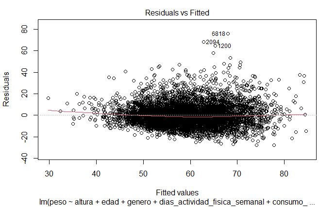

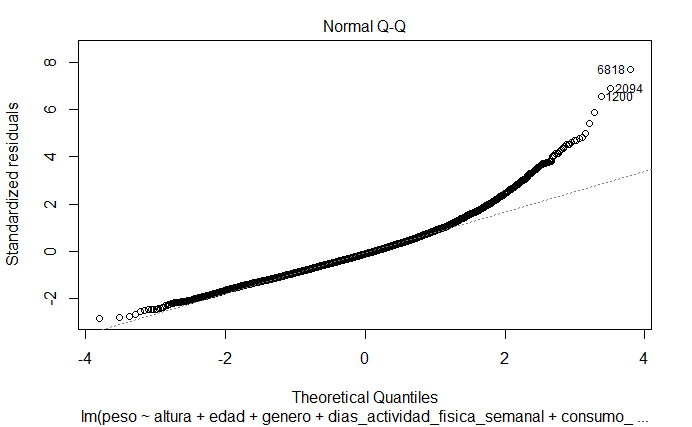

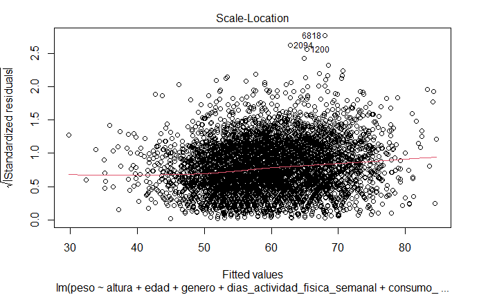

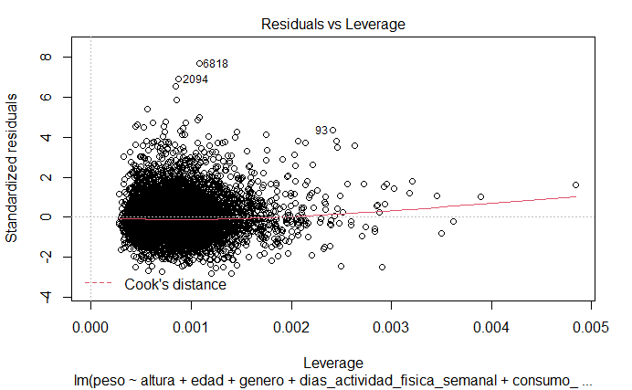

```r
plot(modelo_inicial)
```

- *Residuos vs valores predichos*: Parece existir cierta estructura en los datos: la varianza parece incrementarse con los valores predichos de los extremos, por lo que no se satisface el supuesto de homocedasticidad.
- *Normal QQ plot*: Si bien de izquierda a derecha el QQ plot toma forma bastante lineal, el extremo superior derecho no se ajusta a la distribución teórica.
- *Residual vs leverage*: Existe un punto con un leverage alto.
- *Diagnóstico del modelo*: El modelo creado no logra cumplir con los supuestos del modelo lineal. Parecen existir problemas de heterocedasticidad (varianza no constante), falta de normalidad y presencia de observación de alto leverage.

## Modelo Robusto

**Levantamos otro de los datasets con valores atípicos y observamos su estructura y tipo de variables**

```r
ds_modelo6<- read.csv("encuesta_salud_modelo6.csv")

head(ds_modelo6)
```

|  | record | edad | genero | nivel_educativo | altura | peso | frecuencia_hambre_mensual | dias_consumo_comida_rapida | edad_consumo_alcohol | consumo_diario_alcohol | dias_actividad_fisica_semanal | consumo_semanal_frutas | consumo_semanal_verdura | consumo_semanal_gaseosas | consumo_semanal_snacks | consumo_semanal_comida_grasa | y |
| --- | --- | --- | --- | --- | --- | --- | --- | --- | --- | --- | --- | --- | --- | --- | --- | --- | --- |
| 1 | 502 | 17 | Femenino | 2do año/11vo grado nivel Polimodal o 4to año nivel Secundario | 165 | 62 | Rara vez | 0 | 14 o 15 años | 5 | 7 | No comí frutas durante los últimos 7 días | 4 a 6 veces durante los últimos 7 días | 1 a 3 veces durante los últimos 7 días | 1 a 3 veces durante los últimos 7 días | No comí comida alta en grasa en los últimos 7 días | NA |
| 2 | 26488 | 15 | Masculino | 1er año/10mo grado nivel Polimodal o 3er año nivel Secundario | 178 | 62 | Rara vez | 0 | 7 años o menos | 4 | 7 | No comí frutas durante los últimos 7 días | 4 a 6 veces durante los últimos 7 días | 1 a 3 veces durante los últimos 7 días | No comí comida salada o snacks en los últimos 7 días | 4 a 6 veces durante los últimos 7 días | NA |
| 3 | 31473 | 15 | Masculino | 2do año/11vo grado nivel Polimodal o 4to año nivel Secundario | 172 | 62 | Nunca | 3 | Nunca tomé alcohol más que unos pocos sorbos | 0 | 7 | No comí frutas durante los últimos 7 días | 1 vez al día | 4 a 6 veces durante los últimos 7 días | 4 a 6 veces durante los últimos 7 días | No comí comida alta en grasa en los últimos 7 días | NA |
| 4 | 14154 | 16 | Masculino | 1er año/10mo grado nivel Polimodal o 3er año nivel Secundario | 170 | 65 | Nunca | 1 | 14 o 15 años | 0 | 7 | 4 a 6 veces durante los últimos 7 días | 4 o más veces al día | 1 a 3 veces durante los últimos 7 días | 1 a 3 veces durante los últimos 7 días | No comí comida alta en grasa en los últimos 7 días | NA |
| 5 | 36578 | 17 | Masculino | 2do año/11vo grado nivel Polimodal o 4to año nivel Secundario | 170 | 75 | Rara vez | 1 | 16 o 17 años | 0 | 0 | 2 veces al día | 1 a 3 veces durante los últimos 7 días | 1 vez al día | No comí comida salada o snacks en los últimos 7 días | 1 a 3 veces durante los últimos 7 días | NA |
| 6 | 53730 | 15 | Masculino | 1er año/10mo grado nivel Polimodal o 3er año nivel Secundario | 178 | 88 | Nunca | 2 | 8 o 9 años | 5 | 7 | 1 vez al día | 2 veces al día | 4 a 6 veces durante los últimos 7 días | 4 a 6 veces durante los últimos 7 días | 4 a 6 veces durante los últimos 7 días | NA |

**Relación entre peso y altura**

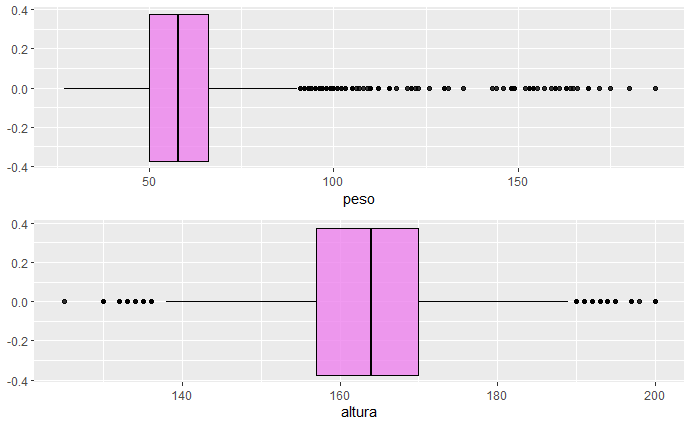

```r
n1<- ggplot(data = ds_modelo6, aes(x = peso)) +
  geom_boxplot(position = "identity", alpha = 0.8, col='black', fill='violet')
n2 <- ggplot(data = ds_modelo6, aes(x = altura)) +
  geom_boxplot(position = "identity", alpha = 0.8, col='black', fill='violet')

grid.arrange(n1, n2)
```

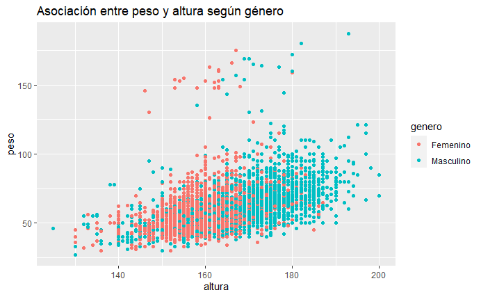

```r
ggplot(ds_modelo6, aes(x = altura, y = peso, color = genero )) +
  geom_point() + labs(title="Asociación entre peso y altura según género")
```

Observamos que frente a la inclusión de observaciones que pueden contener valores atípicos la relación entre *altura* y *peso* se mantiene similar que en **ds_train**, pero con observaciones atípicas mayores que 100kg.

**Chequeamos correlación**

```r
cor(ds_modelo6$altura, ds_modelo6$peso)
```

```
[1] 0.5065739
```

Observamos que frente a estos outliers disminuye la correlación entre ambas variables, pasando de 0.58 en el primer dataset a 0.5 en este.

**Entrenamos el Modelo Inicial en estos datos**

```r
# Ajustamos modelo lineal multiple
modelo_inicial2 <- lm(peso ~ altura + edad + genero + dias_actividad_fisica_semanal + consumo_diario_alcohol, data = ds_modelo6)
# Resumen del modelo
tidy_sc_r2 <- tidy(modelo_inicial2, conf.int = TRUE)
tidy_sc_r2
```

| term | estimate | std.error | statistic | p.value | conf.low | conf.high |
| --- | --- | --- | --- | --- | --- | --- |
| (Intercept) | -70.03018295 | 2.83276287 | -24.7215126 | 1.790765e-129 | -75.5832490 | -64.47711693 |
| altura | 0.66195138 | 0.01742572 | 37.9870250 | 1.870181e-287 | 0.6277917 | 0.69611103 |
| edad | 1.40007823 | 0.11365594 | 12.3185668 | 1.626058e-34 | 1.1772785 | 1.62287800 |
| generoMasculino | 1.03107761 | 0.33064054 | 3.1184246 | 1.825528e-03 | 0.3829228 | 1.67923239 |
| dias_actividad_fisica_semanal | -0.11320339 | 0.06040012 | -1.8742245 | 6.094078e-02 | -0.2316058 | 0.00519899 |
| consumo_diario_alcohol | 0.02083144 | 0.07436556 | 0.2801221 | 7.793920e-01 | -0.1249474 | 0.16661027 |

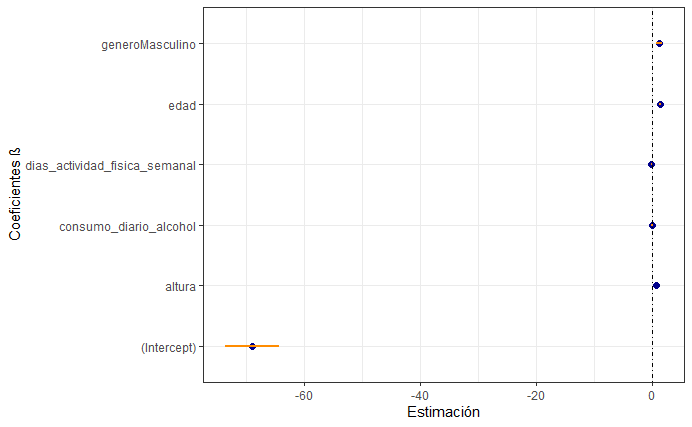

```r
# Plot de los coeficientes
ggplot(tidy_sc_r, aes(estimate, term, xmin = conf.low, xmax = conf.high, height = 0)) +
  geom_point(color = "darkblue",size=2) +
  geom_vline(xintercept = 0, lty = 4, color = "black") +
  geom_errorbarh(color = "darkorange", size=1) +
  theme_bw() +
  labs(y = "Coeficientes β", x = "Estimación")
```

**Armamos lista con las 2 versiones del Modelo Inicial**

```r
models <- list(modelo_inicial = modelo_inicial, modelo_inicial2 = modelo_inicial2)
```

**Calculamos las métricas para los 2 modelos**

```r
df_evaluacion_train = map_df(models, broom::glance, .id = "model") %>%
  # ordenamos por R2 ajustado
  arrange(desc(adj.r.squared))
df_evaluacion_train
```

| model | r.squared | adj.r.squared | sigma | statistic | p.value | df | logLik | AIC | BIC | deviance | df.residual | nobs |
| --- | --- | --- | --- | --- | --- | --- | --- | --- | --- | --- | --- | --- |
| modelo_inicial | 0.3543566 | 0.3538783 | 9.886417 | 740.8277 | 0 | 5 | -25058.73 | 50131.45 | 50179.18 | 659655.6 | 6749 | 6755 |
| modelo_inicial2 | 0.2737421 | 0.2732273 | 12.041342 | 531.7605 | 0 | 5 | -27582.43 | 55178.85 | 55226.89 | 1022787.2 | 7054 | 7060 |

Observamos que en el Modelo Inicial 2, entrenado con estos datos con valores atípicos, disminuye considerablemente el % de variabilidad explicada.

**Hacemos las predicciones en Train y Test**

```r
# Aplicamos la función augment a los modelos
lista_predicciones_training = map(.x = models, .f = augment) # En train

lista_predicciones_testing = map(.x = models, .f = augment, newdata=ds_test) # En test
```

**Evaluamos métricas en train**

```r
# Obtenemos las metricas para el Modelo Inicial
metricas1_train = lista_predicciones_training$modelo_inicial %>%
                 metrics(truth=peso, estimate=.fitted) %>%
                 mutate(.estimate=round(.estimate, 4))

# Obtenemos las metricas para el Modelo Inicial 2
metricas2_train = lista_predicciones_training$modelo_inicial2 %>%
                 metrics(truth=peso, estimate=.fitted) %>%
                 mutate(.estimate=round(.estimate, 4))


metricas1_train # Modelo Inicial
```

| .metric | .estimator | .estimate |
| --- | --- | --- |
| rmse | standard | 9.8820 |
| rsq | standard | 0.3544 |
| mae | standard | 7.4185 |

```r
metricas2_train # Modelo Inicial 2
```

| .metric | .estimator | .estimate |
| --- | --- | --- |
| rmse | standard | 12.0362 |
| rsq | standard | 0.2737 |
| mae | standard | 7.9666 |

Notamos que el error es bastante más amplio en estas métricas para el segundo Modelo Inicial, incluso son errores mayores que en los modelos presentados más arriba.

**Evaluamos métricas en test**

```r
# Obtenemos las metricas para el Modelo Inicial
metricas1_test = lista_predicciones_testing$modelo_inicial %>%
                 metrics(truth=peso, estimate=.fitted) %>%
                 mutate(.estimate=round(.estimate, 4))

# Obtenemos las metricas para el Modelo Inicial 2
metricas2_test = lista_predicciones_testing$modelo_inicial2 %>%
                 metrics(truth=peso, estimate=.fitted) %>%
                 mutate(.estimate=round(.estimate, 4))


metricas1_test # Modelo Inicial
```

| .metric | .estimator | .estimate |
| --- | --- | --- |
| rmse | standard | 10.2114 |
| rsq | standard | 0.3434 |
| mae | standard | 7.5802 |

```r
metricas2_test # Modelo Inicial 2
```

| .metric | .estimator | .estimate |
| --- | --- | --- |
| rmse | standard | 10.2181 |
| rsq | standard | 0.3434 |
| mae | standard | 7.6493 |

Si bien en training la diferencia entre los errores de un modelo y el otro son amplias, en **test** sigue siendo mayor el error en el segundo modelo, aunque con una diferencia menor respecto del primero.

**Conclusiones**: El Modelo Inicial entrenado con datos que contienen outliers predice peor que el entrenado sin outliers. Aumentan las métricas de errores tanto en train como en test.

**Modelo Robusto**

Repetimos lo anterior pero con un modelo robusto que tolere las observaciones *atípicas*.

**Entrenamos el Modelo Inicial en estos datos con el modelo Robusto**

```r
# Ajustamos modelo lineal multiple ROBUSTO
modelo_inicial3 <- rlm(peso ~ altura + edad + genero + dias_actividad_fisica_semanal + consumo_diario_alcohol, data = ds_modelo6)
# Resumen del modelo
tidy_sc_r3 <- tidy(modelo_inicial3, conf.int = TRUE)
tidy_sc_r3
```

| term | estimate | std.error | statistic | conf.low | conf.high |
| --- | --- | --- | --- | --- | --- |
| (Intercept) | -65.93796704 | 2.15453290 | -30.6042981 | -70.1607739 | -61.71516015 |
| altura | 0.63628081 | 0.01325360 | 48.0081649 | 0.6103042 | 0.66225738 |
| edad | 1.30916432 | 0.08644403 | 15.1446462 | 1.1397371 | 1.47859151 |
| generoMasculino | 1.12378525 | 0.25147743 | 4.4687320 | 0.6308985 | 1.61667196 |
| dias_actividad_fisica_semanal | -0.03482499 | 0.04593892 | -0.7580716 | -0.1248636 | 0.05521363 |
| consumo_diario_alcohol | 0.04833042 | 0.05656070 | 0.8544878 | -0.0625265 | 0.15918735 |

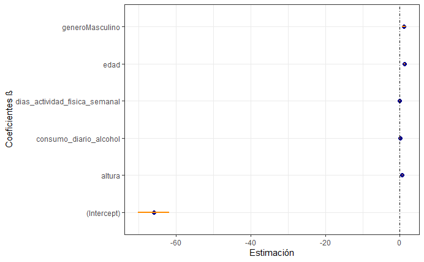

```r
# Plot de los coeficientes
ggplot(tidy_sc_r3, aes(estimate, term, xmin = conf.low, xmax = conf.high, height = 0)) +
  geom_point(color = "darkblue",size=2) +
  geom_vline(xintercept = 0, lty = 4, color = "black") +
  geom_errorbarh(color = "darkorange", size=1) +
  theme_bw() +
  labs(y = "Coeficientes β", x = "Estimación")
```

**Armamos lista con el último modelo creado y el modelo robusto**

```r
models <- list(modelo_inicial2 = modelo_inicial2, modelo_inicial3 = modelo_inicial3)
```

**Hacemos las predicciones en Train y Test**

```r
# Aplicamos la función augment a los modelos
lista_predicciones_training = map(.x = models, .f = augment) # En train

lista_predicciones_testing = map(.x = models, .f = augment, newdata=ds_test) # En test
```

**Evaluamos métricas en train**

```r
# Obtenemos las metricas para el Modelo Inicial 2
metricas2_train = lista_predicciones_training$modelo_inicial2 %>%
                 metrics(truth=peso, estimate=.fitted) %>%
                 mutate(.estimate=round(.estimate, 4))

# Obtenemos las metricas para el Modelo Inicial Robusto
metricas3_train = lista_predicciones_training$modelo_inicial3 %>%
                 metrics(truth=peso, estimate=.fitted) %>%
                 mutate(.estimate=round(.estimate, 4))


metricas2_train # Modelo Inicial 2
```

| .metric | .estimator | .estimate |
| --- | --- | --- |
| rmse | standard | 12.0362 |
| rsq | standard | 0.2737 |
| mae | standard | 7.9666 |

```r
metricas3_train # Modelo Inicial Robusto
```

| .metric | .estimator | .estimate |
| --- | --- | --- |
| rmse | standard | 12.0949 |
| rsq | standard | 0.2735 |
| mae | standard | 7.8610 |

En training vemos que en Modelo Robusto disminuyen el MAE y el RSQ, pero se incrementa el RMSE.

**Evaluamos métricas en test**

```r
# Obtenemos las metricas para el Modelo Inicial 2
metricas2_test = lista_predicciones_testing$modelo_inicial2 %>%
                 metrics(truth=peso, estimate=.fitted) %>%
                 mutate(.estimate=round(.estimate, 4))

# Obtenemos las metricas para el Modelo Inicial Robusto
metricas3_test = lista_predicciones_testing$modelo_inicial3 %>%
                 metrics(truth=peso, estimate=.fitted) %>%
                 mutate(.estimate=round(.estimate, 4))


metricas2_test # Modelo Inicial 2
metricas3_test # Modelo Inicial Robusto
```

[output not shown]